# Abschlussprojekt - Data Analytics von P-2-P-Plattform KIVA

#### Business Understanding

Wir Investieren in die Entwicklung einer benutzerfreundlichen und sicheren Online-Plattform. Diese sollte es den Geldgebern ermöglichen, Projekte zu durchsuchen, Informationen zu den Geschäftsideen zu erhalten und sicher Geld zu investieren. Durch die Analyse der Geschichte unserer Transaktionen müssen wir Insights hervorheben, die uns helfen, unsere Plattform zu verbessern.

Euer Geschäftsmodell ist das Betreiben einer Plattform (crowd-investing) bei der sich Personen die eine Geschäftsidee haben, aber nicht das benötigte Geld, anmelden und für ihr Projekt innerhalb einer vorgegebenen Zeit Geld sammeln können.

Auf der anderen Seite habt ihr Geldgeber, die gern ihr Geld in Projekte anlegen möchten und nach Investitionen suchen.

Als Vermittler bringt eure Plattform also Geldnehmer und Geldgeber zusammen.

Deine Datenbasis ist die Historie eurer Plattform.

Unsere Aufgabe ist es in einer **explorativen Datenanalyse** Insights für eure Plattform herauszufinden.

# Datenaufbereitung

## Step 1: Bibliotheken importieren

```python
import pandas as pd
import plotly.express as px
import numpy as np
import seaborn as sns
import plotly.graph_objects as go
from jupyter_dash import JupyterDash
import warnings
warnings.filterwarnings('ignore')
import matplotlib.pyplot as plt
import dash
from dash import html
from dash import dcc
from dash.dependencies import Input, Output
```

## Step 2: Daten laden (Trennzeichen)

```python
df = pd.read_csv("data_abschlussprojekt.csv",sep="#", index_col=0)
df#.head(3)
```

|  | funded_amount | loan_amount | activity | sector | use | country_code | country | region | currency | term_in_months | lender_count | borrower_genders | repayment_interval |
| --- | --- | --- | --- | --- | --- | --- | --- | --- | --- | --- | --- | --- | --- |
| 0 | 300.0 | 300.0 | Fruits & Vegetables | Food | To buy seasonal, fresh fruits to sell. | PK | Pakistan | Lahore | PKR | 12.0 | 12 | female | irregular |
| 1 | 575.0 | 575.0 | Rickshaw | Transportation | to repair and maintain the auto rickshaw used ... | PK | Pakistan | Lahore | PKR | 11.0 | 14 | female, female | irregular |
| 2 | 150.0 | 150.0 | Transportation | Transportation | To repair their old cycle-van and buy another ... | IN | India | Maynaguri | INR | 43.0 | 6 | female | bullet |
| 3 | 200.0 | 200.0 | Embroidery | Arts | to purchase an embroidery machine and a variet... | PK | Pakistan | Lahore | PKR | 11.0 | 8 | female | irregular |
| 4 | 400.0 | 400.0 | Milk Sales | Food | to purchase one buffalo. | PK | Pakistan | Abdul Hakeem | PKR | 14.0 | 16 | female | monthly |
| ... | ... | ... | ... | ... | ... | ... | ... | ... | ... | ... | ... | ... | ... |
| 671200 | 0.0 | 25.0 | Livestock | Agriculture | [True, u'para compara: cemento, arenya y ladri... | PY | Paraguay | Concepción | USD | 13.0 | 0 | female | monthly |
| 671201 | 25.0 | 25.0 | Livestock | Agriculture | [True, u'to start a turducken farm.'] - this l... | KE | Kenya | NaN | KES | 13.0 | 1 | female | monthly |
| 671202 | 0.0 | 25.0 | Games | Entertainment | NaN | KE | Kenya | NaN | KES | 13.0 | 0 | NaN | monthly |
| 671203 | 0.0 | 25.0 | Livestock | Agriculture | [True, u'to start a turducken farm.'] - this l... | KE | Kenya | NaN | KES | 13.0 | 0 | female | monthly |
| 671204 | 0.0 | 25.0 | Livestock | Agriculture | [True, u'to start a turducken farm.'] - this l... | KE | Kenya | NaN | KES | 13.0 | 0 | female | monthly |

671205 rows × 13 columns

## Step 3: Daten kennenlernen

**Spaltendefinition:**

- funded_amount ... mit Ablauf der "Crowding"zeit erhaltener Betrag/ ausgezahlter Betrag in USD
- loan_amount ... Zielbetrag (Betrag dem man für das Projekt erreichen wollte) in USD
- activity ... Unterkategory zu dem das Ziel des Crowdprojektes thematisch gehört
- sector ... Oberkategory in den das Crowdprojektes Thema fällt
- use ... Kurzbeschreibung wofür das Geld verwendet werden soll
- country_code ... Ländercode nach ISO Norm
- country ... Ländername nach ISO Norm
- region ... Region
- currency ... Währung in den der funded_amount dann ausgezahlt wurde
- term in months ... Dauer über die der Kredit ausgezahlt werden soll
- lender_count ...Darlehensgeber (also wieviele Personen Geld für das Projekt gegeben haben)
- borrower_genders ... Geschlecht und Anzahl der Darlehensnehmer, also diejenigen die das Crowdprojekt initiiert haben
- repayment interval ... vertraglich vereinbarte Rückzahlungsmodalitäten/-rhythmus

```python
df.shape
```

```
(671205, 13)
```

```python
df.info()
```

```
<class 'pandas.core.frame.DataFrame'>
Int64Index: 671205 entries, 0 to 671204
Data columns (total 13 columns):
 #   Column               Non-Null Count   Dtype
---  ------               --------------   -----
 0    funded_amount       671205 non-null  float64
 1    loan_amount         671205 non-null  float64
 2    activity            671205 non-null  object
 3    sector              671205 non-null  object
 4    use                 666973 non-null  object
 5    country_code        671197 non-null  object
 6    country             671205 non-null  object
 7    region              614405 non-null  object
 8    currency            671205 non-null  object
 9    term_in_months      671205 non-null  float64
 10   lender_count        671205 non-null  int64
 11   borrower_genders    666984 non-null  object
 12   repayment_interval  671205 non-null  object
dtypes: float64(3), int64(1), object(9)
memory usage: 71.7+ MB
```

Der Datensatz besteht aus 13 Spalten und 671205 Zeilen.

```python
df.columns.unique()    # Es gibt Leerzeichen in Spaltennamen.
```

```
Index([' funded_amount', ' loan_amount', ' activity', ' sector', ' use',
       ' country_code', ' country', ' region', ' currency', ' term_in_months',
       ' lender_count', ' borrower_genders', ' repayment_interval'],
      dtype='object')
```

Leerzeichen von Spaltennamen entfernen:

```python
df.columns=df.columns.str.strip(' ')        # Leerzeichen von Spaltennamen entfernen
```

```python
df.columns.unique()             # Prüfen ob das funktioniert
```

```
Index(['funded_amount', 'loan_amount', 'activity', 'sector', 'use',
       'country_code', 'country', 'region', 'currency', 'term_in_months',
       'lender_count', 'borrower_genders', 'repayment_interval'],
      dtype='object')
```

```python
df.describe()
```

|  | funded_amount | loan_amount | term_in_months | lender_count |
| --- | --- | --- | --- | --- |
| count | 671205.000000 | 671205.000000 | 671205.000000 | 671205.000000 |
| mean | 785.995061 | 842.397107 | 13.739022 | 20.590922 |
| std | 1130.398941 | 1198.660073 | 8.598919 | 28.459551 |
| min | 0.000000 | 25.000000 | 1.000000 | 0.000000 |
| 25% | 250.000000 | 275.000000 | 8.000000 | 7.000000 |
| 50% | 450.000000 | 500.000000 | 13.000000 | 13.000000 |
| 75% | 900.000000 | 1000.000000 | 14.000000 | 24.000000 |
| max | 100000.000000 | 100000.000000 | 158.000000 | 2986.000000 |

To do:

- Näherer Blick auf den maximalen Wert der Spalte "lender_count" genau.
- Näherer Blick auf den Spalten „funded_amount“ und „loan_amount“, da 75 % der Werte kleiner oder gleich 1.000 $ sind.

```python
df.dtypes
```

```
funded_amount         float64
loan_amount           float64
activity               object
sector                 object
use                    object
country_code           object
country                object
region                 object
currency               object
term_in_months        float64
lender_count            int64
borrower_genders       object
repayment_interval     object
dtype: object
```

Im Allgemeinen passen die Datentypen zu den Spalten an.

```python
df['sector'].unique()
```

```
array(['Food', 'Transportation', 'Arts', 'Services', 'Agriculture',
       'Manufacturing', 'Wholesale', 'Retail', 'Clothing', 'Construction',
       'Health', 'Education', 'Personal Use', 'Housing', 'Entertainment'],
      dtype=object)
```

Die Spalte "sector" hat 15 eindeutige Werte.

```python
df['currency'].unique()
# df['currency'].nunique()
```

```
array(['PKR', 'INR', 'KES', 'NIO', 'USD', 'TZS', 'PHP', 'PEN', 'XOF',
       'LRD', 'VND', 'HNL', 'MNT', 'COP', 'GTQ', 'TJS', 'BOB', 'YER',
       'KHR', 'GHS', 'SLL', 'HTG', 'CLP', 'JOD', 'UGX', 'BIF', 'IDR',
       'GEL', 'UAH', 'EUR', 'ALL', 'CRC', 'XAF', 'TRY', 'AZN', 'DOP',
       'BRL', 'MXN', 'KGS', 'AMD', 'PYG', 'LBP', 'WST', 'ILS', 'RWF',
       'ZMW', 'NPR', 'MZN', 'ZAR', 'BZD', 'SRD', 'NGN', 'VUV', 'XCD',
       'MWK', 'LAK', 'MMK', 'ZWD', 'MDL', 'SSP', 'SBD', 'CNY', 'EGP',
       'MGA', 'NAD', 'LSL', 'THB'], dtype=object)
```

```python
df['activity'].unique()
```

```
array(['Fruits & Vegetables', 'Rickshaw', 'Transportation', 'Embroidery',
       'Milk Sales', 'Services', 'Dairy', 'Beauty Salon', 'Manufacturing',
       'Food Production/Sales', 'Wholesale', 'General Store',
       'Clothing Sales', 'Poultry', 'Tailoring', 'Sewing', 'Bakery',
       'Restaurant', 'Food Stall', 'Farming', 'Construction Supplies',
       'Personal Products Sales', 'Home Products Sales',
       'Natural Medicines', 'Fish Selling', 'Education provider',
       'Shoe Sales', 'Machinery Rental', 'Butcher Shop', 'Pigs',
       'Personal Expenses', 'Food Market', 'Cosmetics Sales',
       'Personal Housing Expenses', 'Retail', 'Energy', 'Grocery Store',
       'Construction', 'Agriculture', 'Motorcycle Transport',
       'Charcoal Sales', 'Food', 'Pharmacy', 'Fishing', 'Timber Sales',
       'Cattle', 'Electronics Repair', 'Electronics Sales', 'Vehicle',
       'Cafe', 'Blacksmith', 'Higher education costs', 'Used Clothing',
       'Fuel/Firewood', 'Upholstery', 'Catering', 'Animal Sales',
       'Cereals', 'Vehicle Repairs', 'Arts',
       'Cloth & Dressmaking Supplies', 'Mobile Phones', 'Spare Parts',
       'Clothing', 'Metal Shop', 'Barber Shop', 'Furniture Making',
       'Crafts', 'Home Energy', 'Home Appliances', 'Wedding Expenses',
       'Taxi', 'Secretarial Services', 'Livestock', 'Property',
       'Recycling', 'Farm Supplies', 'Auto Repair', 'Beverages',
       'Plastics Sales', 'Electrical Goods', 'Carpentry', 'Photography',
       'Jewelry', 'Bricks', 'Pub', 'Phone Use Sales',
       'Water Distribution', 'Paper Sales', 'Computers',
       'Liquor Store / Off-License', 'Utilities', 'Knitting', 'Weaving',
       'Party Supplies', 'Medical Clinic', 'Internet Cafe',
       'Consumer Goods', 'Cement', 'Electrician',
       'Primary/secondary school costs', 'Veterinary Sales',
       'Land Rental', 'Laundry', 'Call Center', 'Perfumes', 'Hotel',
       'Motorcycle Repair', 'Movie Tapes & DVDs', 'Quarrying',
       'Personal Medical Expenses', 'Bookstore', 'Decorations Sales',
       'Recycled Materials', 'Office Supplies', 'Souvenir Sales',
       'Renewable Energy Products', 'Health', 'Printing', 'Phone Repair',
       'Traveling Sales', 'Flowers', 'Bicycle Repair', 'Entertainment',
       'Phone Accessories', 'Hardware', 'Used Shoes',
       'Music Discs & Tapes', 'Games', 'Balut-Making', 'Textiles',
       'Child Care', 'Goods Distribution', 'Florist', 'Cobbler', 'Dental',
       'Bookbinding', 'Cheese Making', 'Bicycle Sales', 'Well digging',
       'Technology', 'Musical Performance', 'Waste Management', 'Film',
       'Tourism', 'Musical Instruments', 'Religious Articles',
       'Machine Shop', 'Cleaning Services', 'Sporting Good Sales',
       'Patchwork', 'Funerals', 'Air Conditioning', 'Communications',
       'Adult Care', 'Landscaping / Gardening', 'Aquaculture',
       'Beekeeping', 'Event Planning', 'Celebrations', 'Computer',
       'Personal Care Products', 'Mobile Transactions'], dtype=object)
```

Spalte "activity" hat 163 eindeutige Werte.

```python
x=df['region'].unique()
x.shape
```

```
(12696,)
```

Mehrere eindeutige Werte. Spalte "region" lassen fuer Analyse +

```python
df['borrower_genders'].unique()
```

```
array(['female', 'female, female', 'female, female, female', ...,
       'female, female, male, female, female, female, female, female, female, female, male, male, female, female, male, female, female, female, female, female, female, female',
       'male, female, female, female, female, female, female, female, male, male, female, male, female, male, male, male',
       'female, female, female, male, female, female, female, male, female, female, female, male, female, male, female, female, female, female, female, female, female, female, female, female, female, female, female, female, male'],
      dtype=object)
```

Spalte "borrower_genders". Die Daten enthalten mehrere Werte in einer Zelle.  
To do: erstellen 3 zusatliche Spalte für Analyse: male_count, female_count, total_count.

```python
df['country_code'].unique()
```

```
array(['PK', 'IN', 'KE', 'NI', 'SV', 'TZ', 'PH', 'PE', 'SN', 'KH', 'LR',
       'VN', 'IQ', 'HN', 'PS', 'MN', 'US', 'ML', 'CO', 'TJ', 'GT', 'EC',
       'BO', 'YE', 'GH', 'SL', 'HT', 'CL', 'JO', 'UG', 'BI', 'BF', 'TL',
       'ID', 'GE', 'UA', 'XK', 'AL', 'CD', 'CR', 'SO', 'ZW', 'CM', 'TR',
       'AZ', 'DO', 'BR', 'MX', 'KG', 'AM', 'PY', 'LB', 'WS', 'IL', 'RW',
       'ZM', 'NP', 'CG', 'MZ', 'ZA', 'TG', 'BJ', 'BZ', 'SR', 'TH', 'NG',
       'MR', 'VU', 'PA', 'VI', 'VC', 'LA', 'MW', 'MM', 'MD', 'SS', 'SB',
       'CN', 'EG', 'GU', 'AF', 'MG', nan, 'PR', 'LS', 'CI', 'BT'],
      dtype=object)
```

Spalte 'country_code' - NaN values  
To do: Ersetzen durch den entsprechenden Wert aus der Spalte "country".

```python
df['country'].unique()
```

```
array(['Pakistan', 'India', 'Kenya', 'Nicaragua', 'El Salvador',
       'Tanzania', 'Philippines', 'Peru', 'Senegal', 'Cambodia',
       'Liberia', 'Vietnam', 'Iraq', 'Honduras', 'Palestine', 'Mongolia',
       'United States', 'Mali', 'Colombia', 'Tajikistan', 'Guatemala',
       'Ecuador', 'Bolivia', 'Yemen', 'Ghana', 'Sierra Leone', 'Haiti',
       'Chile', 'Jordan', 'Uganda', 'Burundi', 'Burkina Faso',
       'Timor-Leste', 'Indonesia', 'Georgia', 'Ukraine', 'Kosovo',
       'Albania', 'The Democratic Republic of the Congo', 'Costa Rica',
       'Somalia', 'Zimbabwe', 'Cameroon', 'Turkey', 'Azerbaijan',
       'Dominican Republic', 'Brazil', 'Mexico', 'Kyrgyzstan', 'Armenia',
       'Paraguay', 'Lebanon', 'Samoa', 'Israel', 'Rwanda', 'Zambia',
       'Nepal', 'Congo', 'Mozambique', 'South Africa', 'Togo', 'Benin',
       'Belize', 'Suriname', 'Thailand', 'Nigeria', 'Mauritania',
       'Vanuatu', 'Panama', 'Virgin Islands',
       'Saint Vincent and the Grenadines',
       "Lao People's Democratic Republic", 'Malawi', 'Myanmar (Burma)',
       'Moldova', 'South Sudan', 'Solomon Islands', 'China', 'Egypt',
       'Guam', 'Afghanistan', 'Madagascar', 'Namibia', 'Puerto Rico',
       'Lesotho', "Cote D'Ivoire", 'Bhutan'], dtype=object)
```

Spalte "country" --> "Democratic Republic of Congo" wechseln zu "Congo".

## Step 4: Duplikate

**Definition:** Alle Spalten überprüfen. Wir könnten alle Spalten in unserem Datensatz überprüfen und Zeilen als Duplikate betrachten, wenn alle Spalten denselben Wert haben. Das bedeutet, dass alle Informationen in der Zeile identisch sind. Danach Schlüsselspalten überprüfen.

### Identifizierung von Duplikaten

```python
duplicates_df = df[df.duplicated(subset=df.columns, keep=False)]
sorted_duplicates = duplicates_df.sort_values(by=list(df.columns))
sorted_duplicates.shape
```

```
(34633, 13)
```

34633 Mit Duplikaten identifizierte Zelle.

```python
duplicates = df[df.duplicated(subset=df.columns)].reset_index(drop=True)

# Dictionary zur Speicherung von Dublettenpaaren erstellen
duplicate_pairs = {}

# Iterieren durch die duplizierten Zeilen
for idx, row in duplicates.iterrows():
    key = tuple(row)                        # Zeile in ein Tupel zur Verwendung als DictionaryKey umwandeln
    if key not in duplicate_pairs:
        duplicate_pairs[key] = [idx]
    else:
        duplicate_pairs[key].append(idx)
i=0
# Print pairs of duplicate indices
for key, indices in duplicate_pairs.items():
    if len(indices) >= 2:
        print(f"Duplicate pair {key} found at indices: {indices}")
    i += 1
print(i)
```

[output not shown]

[output cut: 3644 more lines]

10261 Dublettenpaaren

Testing duplicates:

```python
duplicates = df[df.duplicated(subset=df.columns)].reset_index(drop=True)

# List of specific indices
specific_indices = [305, 314, 788, 808, 823, 824, 834]

# Retrieve rows with specific indices
specific_rows = duplicates.iloc[specific_indices]

# Print the specific rows
specific_rows                               #.shape
```

|  | funded_amount | loan_amount | activity | sector | use | country_code | country | region | currency | term_in_months | lender_count | borrower_genders | repayment_interval |
| --- | --- | --- | --- | --- | --- | --- | --- | --- | --- | --- | --- | --- | --- |
| 305 | 250.0 | 250.0 | Personal Housing Expenses | Housing | to purchase building materials and pay for con... | PH | Philippines | Kananga, Leyte | PHP | 60.0 | 10 | female | irregular |
| 314 | 250.0 | 250.0 | Personal Housing Expenses | Housing | to purchase building materials and pay for con... | PH | Philippines | Kananga, Leyte | PHP | 60.0 | 10 | female | irregular |
| 788 | 250.0 | 250.0 | Personal Housing Expenses | Housing | to purchase building materials and pay for con... | PH | Philippines | Kananga, Leyte | PHP | 60.0 | 10 | female | irregular |
| 808 | 250.0 | 250.0 | Personal Housing Expenses | Housing | to purchase building materials and pay for con... | PH | Philippines | Kananga, Leyte | PHP | 60.0 | 10 | female | irregular |
| 823 | 250.0 | 250.0 | Personal Housing Expenses | Housing | to purchase building materials and pay for con... | PH | Philippines | Kananga, Leyte | PHP | 60.0 | 10 | female | irregular |
| 824 | 250.0 | 250.0 | Personal Housing Expenses | Housing | to purchase building materials and pay for con... | PH | Philippines | Kananga, Leyte | PHP | 60.0 | 10 | female | irregular |
| 834 | 250.0 | 250.0 | Personal Housing Expenses | Housing | to purchase building materials and pay for con... | PH | Philippines | Kananga, Leyte | PHP | 60.0 | 10 | female | irregular |

#### Umgang mit Duplikaten

Duplikate unterscheiden sich nur durch den Index. Damit löschen die Duplikaten außer der ersten.

```python
# Löschen von Duplikaten und Behalten der ersten.
df_no_duplicates = df[~df.duplicated(keep='first')]

# Reset index
df_no_duplicates.reset_index(drop=True, inplace=True)

df_no_duplicates
```

|  | funded_amount | loan_amount | activity | sector | use | country_code | country | region | currency | term_in_months | lender_count | borrower_genders | repayment_interval |
| --- | --- | --- | --- | --- | --- | --- | --- | --- | --- | --- | --- | --- | --- |
| 0 | 300.0 | 300.0 | Fruits & Vegetables | Food | To buy seasonal, fresh fruits to sell. | PK | Pakistan | Lahore | PKR | 12.0 | 12 | female | irregular |
| 1 | 575.0 | 575.0 | Rickshaw | Transportation | to repair and maintain the auto rickshaw used ... | PK | Pakistan | Lahore | PKR | 11.0 | 14 | female, female | irregular |
| 2 | 150.0 | 150.0 | Transportation | Transportation | To repair their old cycle-van and buy another ... | IN | India | Maynaguri | INR | 43.0 | 6 | female | bullet |
| 3 | 200.0 | 200.0 | Embroidery | Arts | to purchase an embroidery machine and a variet... | PK | Pakistan | Lahore | PKR | 11.0 | 8 | female | irregular |
| 4 | 400.0 | 400.0 | Milk Sales | Food | to purchase one buffalo. | PK | Pakistan | Abdul Hakeem | PKR | 14.0 | 16 | female | monthly |
| ... | ... | ... | ... | ... | ... | ... | ... | ... | ... | ... | ... | ... | ... |
| 646828 | 0.0 | 25.0 | Livestock | Agriculture | [True, u'para compara: cemento, arenya y ladri... | PY | Paraguay | Concepción | USD | 13.0 | 0 | female | monthly |
| 646829 | 0.0 | 25.0 | Livestock | Agriculture | Reviewed loan use in english. | PK | Pakistan | Attock | PKR | 13.0 | 0 | female | monthly |
| 646830 | 0.0 | 125.0 | Livestock | Agriculture | Pretend the flagged issue was addressed by KC. | MX | Mexico | Iztacalco | MXN | 13.0 | 0 | female, female | monthly |
| 646831 | 0.0 | 875.0 | Livestock | Agriculture | Translated loan use to english. | BO | Bolivia | La Paz | BOB | 13.0 | 0 | female, female | monthly |
| 646832 | 0.0 | 250.0 | Livestock | Agriculture | Reviewed loan use in english. | GH | Ghana | Dansoman | GHS | 13.0 | 0 | female | monthly |

646833 rows × 13 columns

```python
kia =  len(df) - len(df_no_duplicates)
kia                                         # 24372 Zelle gelöscht
```

```
24372
```

24372 Zelle mit Duplikaten gelöscht.

```python
# Prüfen Sie, ob dies funktioniert
df_no_duplicates.loc[df_no_duplicates.duplicated(subset=df_no_duplicates.columns)].reset_index(drop=True)
```

|  | funded_amount | loan_amount | activity | sector | use | country_code | country | region | currency | term_in_months | lender_count | borrower_genders | repayment_interval |
| --- | --- | --- | --- | --- | --- | --- | --- | --- | --- | --- | --- | --- | --- |

Wir möchten diese Vorstellung von Duplikaten dennoch einschränken, indem wir berücksichtigen, dass „code_country“ und „country“ für eine Zeile unterschiedlich sein können.

```python
df_no_duplicates.columns
```

```
Index(['funded_amount', 'loan_amount', 'activity', 'sector', 'use',
       'country_code', 'country', 'region', 'currency', 'term_in_months',
       'lender_count', 'borrower_genders', 'repayment_interval'],
      dtype='object')
```

```python
df_no_duplicates.loc[df_no_duplicates.duplicated(subset=['funded_amount', 'loan_amount', 'activity', 'sector', 'use',
        'country', 'region', 'currency', 'term_in_months',
       'lender_count', 'borrower_genders', 'repayment_interval'], keep=False) ,:]
```

|  | funded_amount | loan_amount | activity | sector | use | country_code | country | region | currency | term_in_months | lender_count | borrower_genders | repayment_interval |
| --- | --- | --- | --- | --- | --- | --- | --- | --- | --- | --- | --- | --- | --- |

Auch mit diesen Flexibilitaet haben wir die gleiche Ergebniss.

## Step 5: Fehlende Werte

### Schritt 1: Fehlende Werte identifizieren

#### System

```python
missing_count= df_no_duplicates.isnull().sum().sort_values(ascending=False)
missing_percentage= round(df_no_duplicates.isnull().sum()/len(df) * 100,5).sort_values(ascending=False)
result_df = pd.DataFrame({
                        'Missing Count': missing_count,
                        'Missing Percentage': missing_percentage})
result_df_sorted = result_df.sort_values(by='Missing Count', ascending=False)
result_df_sorted
```

|  | Missing Count | Missing Percentage |
| --- | --- | --- |
| region | 56163 | 8.36749 |
| use | 3899 | 0.58090 |
| borrower_genders | 3888 | 0.57926 |
| country_code | 8 | 0.00119 |
| funded_amount | 0 | 0.00000 |
| loan_amount | 0 | 0.00000 |
| activity | 0 | 0.00000 |
| sector | 0 | 0.00000 |
| country | 0 | 0.00000 |
| currency | 0 | 0.00000 |
| term_in_months | 0 | 0.00000 |
| lender_count | 0 | 0.00000 |
| repayment_interval | 0 | 0.00000 |

```python
df_no_duplicates[df_no_duplicates['country_code'].isna()]
```

|  | funded_amount | loan_amount | activity | sector | use | country_code | country | region | currency | term_in_months | lender_count | borrower_genders | repayment_interval |
| --- | --- | --- | --- | --- | --- | --- | --- | --- | --- | --- | --- | --- | --- |
| 198369 | 4150.0 | 4150.0 | Wholesale | Wholesale | To purchase lighting products for sale to loca... | NaN | Namibia | EEnhana | NAD | 6.0 | 162 | female | bullet |
| 198646 | 4150.0 | 4150.0 | Wholesale | Wholesale | To purchase lighting products for sale to loca... | NaN | Namibia | Rundu | NAD | 6.0 | 159 | male | bullet |
| 337622 | 3325.0 | 3325.0 | Wholesale | Wholesale | To purchase lighting products for sale to loca... | NaN | Namibia | EEnhana | NAD | 7.0 | 120 | female | bullet |
| 343771 | 3325.0 | 3325.0 | Wholesale | Wholesale | To purchase lighting products for sale to loca... | NaN | Namibia | Rundu | NAD | 7.0 | 126 | male | bullet |
| 411637 | 3325.0 | 3325.0 | Wholesale | Wholesale | To purchase lighting products for sale to loca... | NaN | Namibia | EEnhana | NAD | 7.0 | 118 | female | bullet |
| 411895 | 4000.0 | 4000.0 | Wholesale | Wholesale | purchase solar lighting products for sale to l... | NaN | Namibia | Rundu | NAD | 7.0 | 150 | male | bullet |
| 474672 | 5100.0 | 5100.0 | Renewable Energy Products | Retail | to pay for stock of solar lights and cell phon... | NaN | Namibia | Katima Mulilo | NAD | 7.0 | 183 | male | bullet |
| 475099 | 5000.0 | 5000.0 | Wholesale | Wholesale | to maintain a stock of solar lights and cell p... | NaN | Namibia | Oshakati | NAD | 7.0 | 183 | female | bullet |

```python
# Prüfe alle Einträge mit "country_code"= NaN oder Land "namibia" string enthält oder ob es andere country_code=NAM Einträge gibt
df_no_code = df_no_duplicates[
                            (df_no_duplicates["country_code"].isna())
                            | (df_no_duplicates["country_code"] =='NAM')
                            | (df_no_duplicates['country'].str.contains('namibia', case=False))
                            ]
df_no_code
```

|  | funded_amount | loan_amount | activity | sector | use | country_code | country | region | currency | term_in_months | lender_count | borrower_genders | repayment_interval |
| --- | --- | --- | --- | --- | --- | --- | --- | --- | --- | --- | --- | --- | --- |
| 198369 | 4150.0 | 4150.0 | Wholesale | Wholesale | To purchase lighting products for sale to loca... | NaN | Namibia | EEnhana | NAD | 6.0 | 162 | female | bullet |
| 198646 | 4150.0 | 4150.0 | Wholesale | Wholesale | To purchase lighting products for sale to loca... | NaN | Namibia | Rundu | NAD | 6.0 | 159 | male | bullet |
| 337622 | 3325.0 | 3325.0 | Wholesale | Wholesale | To purchase lighting products for sale to loca... | NaN | Namibia | EEnhana | NAD | 7.0 | 120 | female | bullet |
| 343771 | 3325.0 | 3325.0 | Wholesale | Wholesale | To purchase lighting products for sale to loca... | NaN | Namibia | Rundu | NAD | 7.0 | 126 | male | bullet |
| 411637 | 3325.0 | 3325.0 | Wholesale | Wholesale | To purchase lighting products for sale to loca... | NaN | Namibia | EEnhana | NAD | 7.0 | 118 | female | bullet |
| 411895 | 4000.0 | 4000.0 | Wholesale | Wholesale | purchase solar lighting products for sale to l... | NaN | Namibia | Rundu | NAD | 7.0 | 150 | male | bullet |
| 474672 | 5100.0 | 5100.0 | Renewable Energy Products | Retail | to pay for stock of solar lights and cell phon... | NaN | Namibia | Katima Mulilo | NAD | 7.0 | 183 | male | bullet |
| 475099 | 5000.0 | 5000.0 | Wholesale | Wholesale | to maintain a stock of solar lights and cell p... | NaN | Namibia | Oshakati | NAD | 7.0 | 183 | female | bullet |

```python
df_no_code.shape                    # Füllen im weiteren Verlauf NaN mit "NAM" aus
```

```
(8, 13)
```

#### Synonyme finden

```python
# Erstellen einer Funktion zur Suche nach Sonderzeichen
class ScriptAggregator:
    def __init__(self, df):
        self.df = df
        self.special_characters = {'"', "\n", '!', '@', '#', '$', '%', '^', '&', '*', '(', ')', '-', '_', '+', '=', '[', ']', '{', '}', ';', ':', '<', '>', ',', '.', '/', '?', '|', '\\'}

    def get_common_records(self):
        common_records = {
            "df1": self.df[self.df["funded_amount"].isin(self.special_characters)],
            "df2": self.df[self.df["loan_amount"].isin(self.special_characters)],
            "df3": self.df[self.df["activity"].isin(self.special_characters)],
            "df4": self.df[self.df["sector"].isin(self.special_characters)],
            "df5": self.df[self.df["use"].isin(self.special_characters)],
            "df6": self.df[self.df["country_code"].isin(self.special_characters)],
            "df7": self.df[self.df["country"].isin(self.special_characters)],
            "df8": self.df[self.df["region"].isin(self.special_characters)],
            "df9": self.df[self.df["currency"].isin(self.special_characters)],
            "df10": self.df[self.df["term_in_months"].isin(self.special_characters)],
            "df11": self.df[self.df["lender_count"].isin(self.special_characters)],
            "df12": self.df[self.df["borrower_genders"].isin(self.special_characters)],
            "df13": self.df[self.df["repayment_interval"].isin(self.special_characters)]
        }
        return common_records


aggregator = ScriptAggregator(df_no_duplicates)
common_records = aggregator.get_common_records()

# Zugriff auf common_records_df1, common_records_df2 usw. aus dem common_records-Dictionary
# For example:
print(common_records["df1"])
print(common_records["df2"])
print(common_records["df3"])
print(common_records["df4"])
print(common_records["df5"])
print(common_records["df6"])
print(common_records["df7"])
print(common_records["df8"])
print(common_records["df9"])
print(common_records["df10"])
print(common_records["df11"])
print(common_records["df12"])
print(common_records["df13"])
```

```
Empty DataFrame
Columns: [funded_amount, loan_amount, activity, sector, use, country_code, country, region, currency, term_in_months, lender_count, borrower_genders, repayment_interval]
Index: []
Empty DataFrame
Columns: [funded_amount, loan_amount, activity, sector, use, country_code, country, region, currency, term_in_months, lender_count, borrower_genders, repayment_interval]
Index: []
Empty DataFrame
Columns: [funded_amount, loan_amount, activity, sector, use, country_code, country, region, currency, term_in_months, lender_count, borrower_genders, repayment_interval]
Index: []
Empty DataFrame
Columns: [funded_amount, loan_amount, activity, sector, use, country_code, country, region, currency, term_in_months, lender_count, borrower_genders, repayment_interval]
Index: []
        funded_amount  loan_amount     activity       sector use country_code  \
130762           75.0       5000.0  Agriculture  Agriculture   .           US

              country region currency  term_in_months  lender_count  \
130762  United States    NaN      USD            24.0             7

       borrower_genders repayment_interval
130762           female             bullet
Empty DataFrame
Columns: [funded_amount, loan_amount, activity, sector, use, country_code, country, region, currency, term_in_months, lender_count, borrower_genders, repayment_interval]
Index: []
Empty DataFrame
Columns: [funded_amount, loan_amount, activity, sector, use, country_code, country, region, currency, term_in_months, lender_count, borrower_genders, repayment_interval]
Index: []
Empty DataFrame
Columns: [funded_amount, loan_amount, activity, sector, use, country_code, country, region, currency, term_in_months, lender_count, borrower_genders, repayment_interval]
Index: []
Empty DataFrame
Columns: [funded_amount, loan_amount, activity, sector, use, country_code, country, region, currency, term_in_months, lender_count, borrower_genders, repayment_interval]
Index: []
Empty DataFrame
Columns: [funded_amount, loan_amount, activity, sector, use, country_code, country, region, currency, term_in_months, lender_count, borrower_genders, repayment_interval]
Index: []
Empty DataFrame
Columns: [funded_amount, loan_amount, activity, sector, use, country_code, country, region, currency, term_in_months, lender_count, borrower_genders, repayment_interval]
Index: []
Empty DataFrame
Columns: [funded_amount, loan_amount, activity, sector, use, country_code, country, region, currency, term_in_months, lender_count, borrower_genders, repayment_interval]
Index: []
Empty DataFrame
Columns: [funded_amount, loan_amount, activity, sector, use, country_code, country, region, currency, term_in_months, lender_count, borrower_genders, repayment_interval]
Index: []
```

Bei Index 130762 steht ein "." in der Spalte "use"

### Was machen wir mit den fehlenden Werten?

Ersetzen "The Democratic Republic of the Congo" durch Congo:

```python
# Ersetzen "The Democratic Republic of the Congo" durch Congo
df_no_duplicates.loc[df_no_duplicates['country'] == 'The Democratic Republic of the Congo', 'country'] = 'Congo'

# Check if no more null
df_no_duplicates.loc[df_no_duplicates['country'] == 'The Democratic Republic of the Congo', 'country']
```

```
Series([], Name: country, dtype: object)
```

Ersetzen NAN Value in "country_code" Spalte mit dem entsprechenden Country code:

```python
# Hier wird NAN Value in "country_code" Spalte mit dem entsprechenden Country code ersetzt.
df_no_duplicates.loc[df_no_duplicates['country'] == 'Namibia', 'country_code'] = 'NAM'

# Hier wird geprüft, ob noch die NAN-Value in Country_Code Spalte steht.
df_no_duplicates[df_no_duplicates["country_code"].isna()]
```

|  | funded_amount | loan_amount | activity | sector | use | country_code | country | region | currency | term_in_months | lender_count | borrower_genders | repayment_interval |
| --- | --- | --- | --- | --- | --- | --- | --- | --- | --- | --- | --- | --- | --- |

```python
df_no_duplicates.isna().sum().sort_values(ascending=False)
```

```
region                56163
use                    3899
borrower_genders       3888
funded_amount             0
loan_amount               0
activity                  0
sector                    0
country_code              0
country                   0
currency                  0
term_in_months            0
lender_count              0
repayment_interval        0
dtype: int64
```

```python
# Gesamtes Investitionsvolumen
x = df_no_duplicates["funded_amount"].sum()
x
```

```
522540915.0
```

```python
# # Gesamtes Investitionsvolumen für borowed_gender mit NaN
y= df_no_duplicates.loc[df_no_duplicates["borrower_genders"].isna(), "funded_amount"].sum()
y
```

```
3804855.0
```

```python
print(f"{round((y*100/x), 3)} %")
```

```
0.728 %
```

The total sum of investments in projects, which have in "borrower_genders" NaN, is $3.8M. Im Vergleich zu den Gesamtinvestitionen von $522M macht das 0,728%.  
Entscheidung: Lösche 3888 Zeilen mit fehlenden Werten in der Spalte "borrower_genders". So können wir eine Analyse nach Geschlecht in weiteren durchführen.

```python
df_no_duplicates = df_no_duplicates.dropna(subset=["borrower_genders"])
```

```python
df_no_duplicates.isna().sum()
```

```
funded_amount             0
loan_amount               0
activity                  0
sector                    0
use                      11
country_code              0
country                   0
region                52275
currency                  0
term_in_months            0
lender_count              0
borrower_genders          0
repayment_interval        0
dtype: int64
```

- 'country_code' - redundant Information, weil "country" Spalte mehr Information hat. Wir löschen den country code, da der Inhalt nicht wichtig ist.
- "region" - Unsere Analyse basiert auf Ländern und nicht auf Regionen innerhalb jedes Landes
- "use" - Die Spalte use ist in unserer Analyse nicht wichtig, da die Aktivität für unsere Analyse wichtiger ist. Darüber hinaus diese Spalte 'use' benötigt viel speichern Platz

```python
# Loeschen Spalten: 'country_code', "region", "use"
df_no_duplicates.drop(columns=['country_code', "region", "use"], inplace=True)
```

```python
df_no_duplicates.memory_usage(deep=True).sort_values(ascending=False)
```

```
borrower_genders      45267539
activity              44508755
country               41987140
sector                41717581
repayment_interval    41582093
currency              38576700
Index                  5143560
funded_amount          5143560
loan_amount            5143560
term_in_months         5143560
lender_count           5143560
dtype: int64
```

```python
df_no_duplicates.isna().sum().sort_values(ascending=False)
```

```
funded_amount         0
loan_amount           0
activity              0
sector                0
country               0
currency              0
term_in_months        0
lender_count          0
borrower_genders      0
repayment_interval    0
dtype: int64
```

```python
df_no_duplicates.shape
```

```
(642945, 10)
```

### Step 5.5: Erste univariate Analyse für einen Überblick (scatterplot)

Aufteilung der Werte in der Spalte "borrower_genders" in separate Spalten nach Anzahl der Vorkommen:

```python
df_pre_clean = df_no_duplicates.copy()
```

```python
df_pre_clean.loc[(df_no_duplicates['funded_amount']>11000),:].sort_values(by="funded_amount", ascending=True)
```

|  | funded_amount | loan_amount | activity | sector | country | currency | term_in_months | lender_count | borrower_genders | repayment_interval |
| --- | --- | --- | --- | --- | --- | --- | --- | --- | --- | --- |
| 102896 | 11025.0 | 11025.0 | Farm Supplies | Agriculture | Myanmar (Burma) | MMK | 6.0 | 332 | male | bullet |
| 324797 | 11250.0 | 11250.0 | Home Energy | Personal Use | Kenya | KES | 62.0 | 376 | male, male, female, male, male, female, male, ... | irregular |
| 35417 | 11575.0 | 11575.0 | Water Distribution | Services | Dominican Republic | DOP | 38.0 | 457 | male | monthly |
| 115539 | 11650.0 | 11650.0 | Pharmacy | Health | Yemen | YER | 18.0 | 354 | male | monthly |
| 31914 | 11650.0 | 11650.0 | Bakery | Food | Yemen | YER | 15.0 | 312 | male | monthly |
| ... | ... | ... | ... | ... | ... | ... | ... | ... | ... | ... |
| 528880 | 50000.0 | 50000.0 | Health | Health | South Sudan | USD | 8.0 | 1609 | female | bullet |
| 532578 | 50000.0 | 50000.0 | Renewable Energy Products | Retail | Zimbabwe | USD | 13.0 | 720 | male | monthly |
| 546130 | 50000.0 | 50000.0 | Renewable Energy Products | Retail | Kenya | USD | 14.0 | 1402 | female | irregular |
| 53167 | 50000.0 | 50000.0 | Renewable Energy Products | Retail | Uganda | USD | 14.0 | 1581 | female | bullet |
| 69745 | 100000.0 | 100000.0 | Agriculture | Agriculture | Haiti | USD | 75.0 | 2986 | female | irregular |

152 rows × 10 columns

Die meisten Projekte haben einen Investitionsbetrag von weniger als oder gleich 10.000. Nur 152 Projekte haben einen Investitionsbetrag von mehr als 11.000

```python
# Scatterdiagram für die Verteilung der funded_amount
fig = px.scatter(df_pre_clean, x=df_pre_clean.index, y='funded_amount', title="ScatterPlot für  Total von 'funded_amount'")

fig.show()
```

[output not shown]

## Step 6: Extremwert vs. Ausreißer

```python
df_pre_clean.describe()
```

|  | funded_amount | loan_amount | term_in_months | lender_count |
| --- | --- | --- | --- | --- |
| count | 642945.000000 | 642945.000000 | 642945.000000 | 642945.000000 |
| mean | 806.812496 | 863.934046 | 13.709058 | 21.066614 |
| std | 1142.722641 | 1203.029886 | 8.476373 | 28.739241 |
| min | 0.000000 | 25.000000 | 1.000000 | 0.000000 |
| 25% | 275.000000 | 275.000000 | 8.000000 | 7.000000 |
| 50% | 475.000000 | 500.000000 | 13.000000 | 13.000000 |
| 75% | 925.000000 | 1000.000000 | 14.000000 | 25.000000 |
| max | 100000.000000 | 100000.000000 | 158.000000 | 2986.000000 |

```python
f_check=df_pre_clean.loc[df_pre_clean['lender_count'] >1700]         # Maximal Werte von lender_count Spalte anschauen
f_check
```

|  | funded_amount | loan_amount | activity | sector | country | currency | term_in_months | lender_count | borrower_genders | repayment_interval |
| --- | --- | --- | --- | --- | --- | --- | --- | --- | --- | --- |
| 69745 | 100000.0 | 100000.0 | Agriculture | Agriculture | Haiti | USD | 75.0 | 2986 | female | irregular |
| 495357 | 50000.0 | 50000.0 | Poultry | Agriculture | Tanzania | USD | 14.0 | 1765 | female | irregular |
| 610257 | 50000.0 | 50000.0 | Agriculture | Agriculture | Cote D'Ivoire | USD | 10.0 | 1706 | female | irregular |

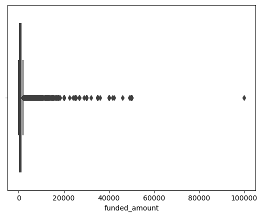

```python
# Maximal Werte von lender_count Spalte mit Boxplot anschauen
sns.boxplot(x='funded_amount', data=df_pre_clean)
```

```python
# Definieren bins
bin_edges = [-1, 999, 4999, 10000, float('inf')]

# Definieren die Labels für die Kategorien
bin_labels = ['<1000', '1000-5000', '5000-10000', '>10000']

# Anwenden der Kategorisierung auf den DataFrame
df_pre_clean['funded_amount_category'] = pd.cut(df_pre_clean['funded_amount'], bins=bin_edges, labels=bin_labels)
df_pre_clean
```

|  | funded_amount | loan_amount | activity | sector | country | currency | term_in_months | lender_count | borrower_genders | repayment_interval | funded_amount_category |
| --- | --- | --- | --- | --- | --- | --- | --- | --- | --- | --- | --- |
| 0 | 300.0 | 300.0 | Fruits & Vegetables | Food | Pakistan | PKR | 12.0 | 12 | female | irregular | <1000 |
| 1 | 575.0 | 575.0 | Rickshaw | Transportation | Pakistan | PKR | 11.0 | 14 | female, female | irregular | <1000 |
| 2 | 150.0 | 150.0 | Transportation | Transportation | India | INR | 43.0 | 6 | female | bullet | <1000 |
| 3 | 200.0 | 200.0 | Embroidery | Arts | Pakistan | PKR | 11.0 | 8 | female | irregular | <1000 |
| 4 | 400.0 | 400.0 | Milk Sales | Food | Pakistan | PKR | 14.0 | 16 | female | monthly | <1000 |
| ... | ... | ... | ... | ... | ... | ... | ... | ... | ... | ... | ... |
| 646828 | 0.0 | 25.0 | Livestock | Agriculture | Paraguay | USD | 13.0 | 0 | female | monthly | <1000 |
| 646829 | 0.0 | 25.0 | Livestock | Agriculture | Pakistan | PKR | 13.0 | 0 | female | monthly | <1000 |
| 646830 | 0.0 | 125.0 | Livestock | Agriculture | Mexico | MXN | 13.0 | 0 | female, female | monthly | <1000 |
| 646831 | 0.0 | 875.0 | Livestock | Agriculture | Bolivia | BOB | 13.0 | 0 | female, female | monthly | <1000 |
| 646832 | 0.0 | 250.0 | Livestock | Agriculture | Ghana | GHS | 13.0 | 0 | female | monthly | <1000 |

642945 rows × 11 columns

```python
# Prüfen ob das funktioniert
df_pre_clean["funded_amount_category"].isna().sum()
```

```
0
```

```python
# Anzahl nach Kategorie
category_counts = df_pre_clean['funded_amount_category'].value_counts()
category_counts
```

```
<1000         493230
1000-5000     139915
5000-10000      9635
>10000           165
Name: funded_amount_category, dtype: int64
```

### Definition

Nach einer Analyse nach Investitionskategorien haben wir festgestellt, dass nur 165 Projekte einen Investitionsbetrag von mehr als 10.000 aufweisen. Aus diesem Grund ist es ganz logisch, diese Projekte als „Ausreisser“ zu betrachten.

Wir haben auch herausgefunden, dass nur ein Projekt einen Investitionsbetrag von 100.000 hat. Und was besonderes ist, dieses Projekt in Haiti zu finden. Dieser Wert kann als Extremwert angesehen werden.

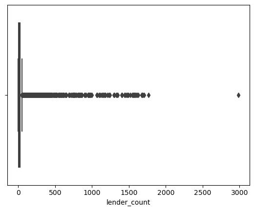

```python
sns.boxplot(x='lender_count', data=df_pre_clean)
```

```python
df_pre_clean.describe()
```

|  | funded_amount | loan_amount | term_in_months | lender_count |
| --- | --- | --- | --- | --- |
| count | 642945.000000 | 642945.000000 | 642945.000000 | 642945.000000 |
| mean | 806.812496 | 863.934046 | 13.709058 | 21.066614 |
| std | 1142.722641 | 1203.029886 | 8.476373 | 28.739241 |
| min | 0.000000 | 25.000000 | 1.000000 | 0.000000 |
| 25% | 275.000000 | 275.000000 | 8.000000 | 7.000000 |
| 50% | 475.000000 | 500.000000 | 13.000000 | 13.000000 |
| 75% | 925.000000 | 1000.000000 | 14.000000 | 25.000000 |
| max | 100000.000000 | 100000.000000 | 158.000000 | 2986.000000 |

```python
ff=df_pre_clean.loc[df_pre_clean['lender_count'] >1700]
ff
```

|  | funded_amount | loan_amount | activity | sector | country | currency | term_in_months | lender_count | borrower_genders | repayment_interval | funded_amount_category |
| --- | --- | --- | --- | --- | --- | --- | --- | --- | --- | --- | --- |
| 69745 | 100000.0 | 100000.0 | Agriculture | Agriculture | Haiti | USD | 75.0 | 2986 | female | irregular | >10000 |
| 495357 | 50000.0 | 50000.0 | Poultry | Agriculture | Tanzania | USD | 14.0 | 1765 | female | irregular | >10000 |
| 610257 | 50000.0 | 50000.0 | Agriculture | Agriculture | Cote D'Ivoire | USD | 10.0 | 1706 | female | irregular | >10000 |

Kategorisierung von 'lender_count' Spalte:

```python
# Definieren bins
bin_edges = [-1, 99, 499, 1499, 3000]

# Definieren die Labels für die Kategorien
bin_labels = ['<100', '100-499', '500-1499', '1500-3000']

# Anwenden der Kategorisierung auf den DataFrame
df_pre_clean['lender_count_category'] = pd.cut(df_pre_clean['lender_count'], bins=bin_edges, labels=bin_labels)
df_pre_clean.isna().sum()
```

```
funded_amount             0
loan_amount               0
activity                  0
sector                    0
country                   0
currency                  0
term_in_months            0
lender_count              0
borrower_genders          0
repayment_interval        0
funded_amount_category    0
lender_count_category     0
dtype: int64
```

```python
# Anzahl nach Kategorie
category_counts = df_pre_clean['lender_count_category'].value_counts()
category_counts
```

```
<100         629775
100-499       13063
500-1499         90
1500-3000        17
Name: lender_count_category, dtype: int64
```

Die Projekte, an denen mehr als 500 Investoren beteiligt sind, liegen nicht über 107. Daher können wir sie als Ausreißer betrachten.

Ausreißer könnten tatsächlich wichtige und informative Muster oder Besonderheiten in den Daten darstellen, die für die Analyse relevant sein könnten. In unseren Fall nur 165 Investments sind grosser als 10000 und nach Kategorien analysieren zu können, Extremwerte und Ausreißer auslassen.

## Step 7: Kennzahlen berechnen / Feature Engineering

# EDA

Korrelationsanalyse: wir können die Korrelationen zwischen den numerischen Spalten (z.B. 'funded_amount', 'loan_amount', 'term_in_months', 'lender_count') untersuchen, um zu sehen, wie diese miteinander zusammenhängen. Dies kann helfen, Muster und Beziehungen zwischen den finanziellen Aspekten zu erkennen.

```python
# Korrelation Analyse
df_corr = df_pre_clean.corr(method="pearson")
df_corr
```

|  | funded_amount | loan_amount | term_in_months | lender_count |
| --- | --- | --- | --- | --- |
| funded_amount | 1.000000 | 0.951366 | 0.153446 | 0.846736 |
| loan_amount | 0.951366 | 1.000000 | 0.190608 | 0.801482 |
| term_in_months | 0.153446 | 0.190608 | 1.000000 | 0.233383 |
| lender_count | 0.846736 | 0.801482 | 0.233383 | 1.000000 |

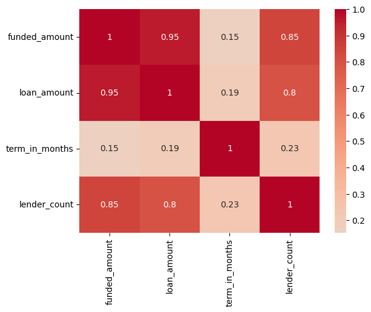

```python
sns.heatmap(df_corr,
            center=0,  # Farbskala ist bei 0 zentriert
            cmap="coolwarm", # Farbskala startet bei 0 und entwickelt sich gegengesetzt
            annot=True       # Der Korrelationskoeffizient soll angezeigt werden
           )
```

Hier sehen wir eine starke Korreleation zwischen:

1. "loan_amount" und "funded_amount"
2. "lender_count" und "loan_amount" und "funded_amount"

Multiple Pairplot für numerische Werten

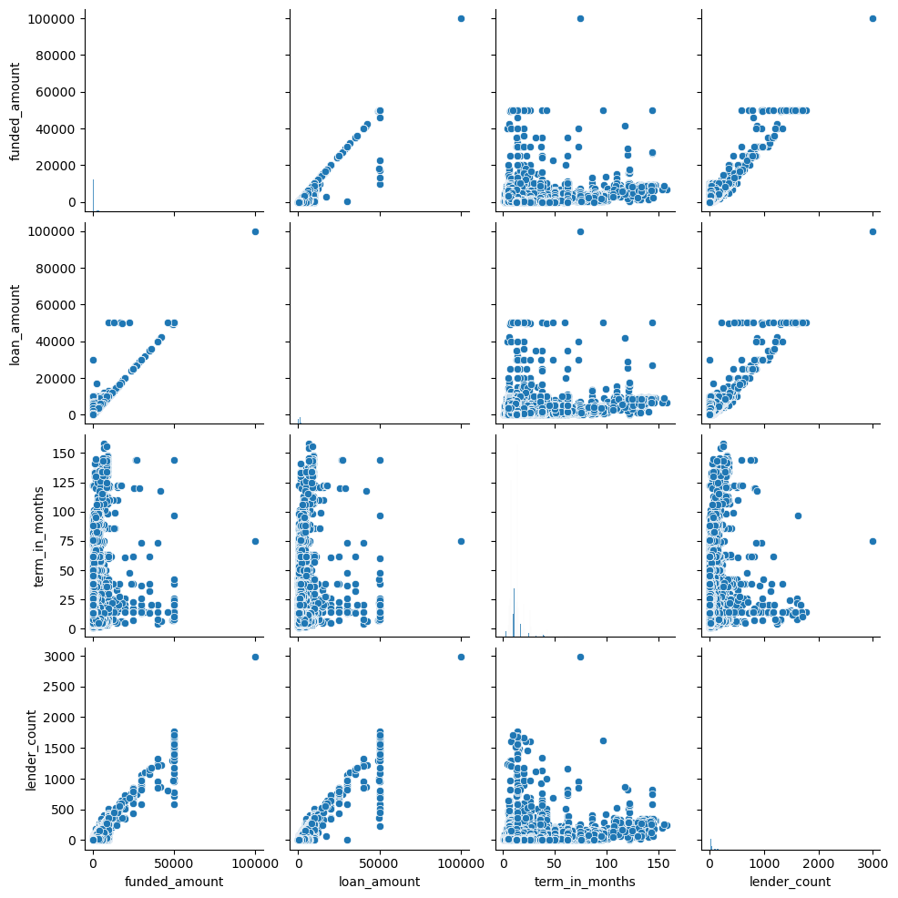

```python
# Relevante numerische Spalten auswählen
numeric_columns = ['funded_amount', 'loan_amount', 'term_in_months', 'lender_count']

# Erstellen pair plot
sns.pairplot(df_pre_clean[numeric_columns])
plt.show()
```

Wir können untersuchen, welche Sektoren oder Aktivitäten tendenziell höhere funded_amount erhalten oder schneller repayment_interval.

```python
df_pre_clean.head(5)
```

|  | funded_amount | loan_amount | activity | sector | country | currency | term_in_months | lender_count | borrower_genders | repayment_interval | funded_amount_category | lender_count_category |
| --- | --- | --- | --- | --- | --- | --- | --- | --- | --- | --- | --- | --- |
| 0 | 300.0 | 300.0 | Fruits & Vegetables | Food | Pakistan | PKR | 12.0 | 12 | female | irregular | <1000 | <100 |
| 1 | 575.0 | 575.0 | Rickshaw | Transportation | Pakistan | PKR | 11.0 | 14 | female, female | irregular | <1000 | <100 |
| 2 | 150.0 | 150.0 | Transportation | Transportation | India | INR | 43.0 | 6 | female | bullet | <1000 | <100 |
| 3 | 200.0 | 200.0 | Embroidery | Arts | Pakistan | PKR | 11.0 | 8 | female | irregular | <1000 | <100 |
| 4 | 400.0 | 400.0 | Milk Sales | Food | Pakistan | PKR | 14.0 | 16 | female | monthly | <1000 | <100 |

## Step 8: Informationen extrahieren (z.B. Jahr oder Wochentag aus Datum ziehen)

Kategorisieren die Gender in drei neuen Spalten:

```python
df_pre_clean['male_count'] = (df_pre_clean['borrower_genders'].str.count(r'\bmale\b'))              # male count Spalte

df_pre_clean['female_count'] = (df_pre_clean['borrower_genders'].str.count(r'\bfemale\b'))          # male count Spalte

df_pre_clean['total_borrowers'] = (df_pre_clean['male_count'] + df_pre_clean['female_count'])   # total Anzahl von borrowers Spalte

df_pre_clean
```

|  | funded_amount | loan_amount | activity | sector | country | currency | term_in_months | lender_count | borrower_genders | repayment_interval | funded_amount_category | lender_count_category | male_count | female_count | total_borrowers |
| --- | --- | --- | --- | --- | --- | --- | --- | --- | --- | --- | --- | --- | --- | --- | --- |
| 0 | 300.0 | 300.0 | Fruits & Vegetables | Food | Pakistan | PKR | 12.0 | 12 | female | irregular | <1000 | <100 | 0 | 1 | 1 |
| 1 | 575.0 | 575.0 | Rickshaw | Transportation | Pakistan | PKR | 11.0 | 14 | female, female | irregular | <1000 | <100 | 0 | 2 | 2 |
| 2 | 150.0 | 150.0 | Transportation | Transportation | India | INR | 43.0 | 6 | female | bullet | <1000 | <100 | 0 | 1 | 1 |
| 3 | 200.0 | 200.0 | Embroidery | Arts | Pakistan | PKR | 11.0 | 8 | female | irregular | <1000 | <100 | 0 | 1 | 1 |
| 4 | 400.0 | 400.0 | Milk Sales | Food | Pakistan | PKR | 14.0 | 16 | female | monthly | <1000 | <100 | 0 | 1 | 1 |
| ... | ... | ... | ... | ... | ... | ... | ... | ... | ... | ... | ... | ... | ... | ... | ... |
| 646828 | 0.0 | 25.0 | Livestock | Agriculture | Paraguay | USD | 13.0 | 0 | female | monthly | <1000 | <100 | 0 | 1 | 1 |
| 646829 | 0.0 | 25.0 | Livestock | Agriculture | Pakistan | PKR | 13.0 | 0 | female | monthly | <1000 | <100 | 0 | 1 | 1 |
| 646830 | 0.0 | 125.0 | Livestock | Agriculture | Mexico | MXN | 13.0 | 0 | female, female | monthly | <1000 | <100 | 0 | 2 | 2 |
| 646831 | 0.0 | 875.0 | Livestock | Agriculture | Bolivia | BOB | 13.0 | 0 | female, female | monthly | <1000 | <100 | 0 | 2 | 2 |
| 646832 | 0.0 | 250.0 | Livestock | Agriculture | Ghana | GHS | 13.0 | 0 | female | monthly | <1000 | <100 | 0 | 1 | 1 |

642945 rows × 15 columns

Einteilung der Borrowers in drei Gruppen: 'Only Female', 'Only Male', 'Mixed Gender'.

```python
# Einteilung der Kreditnehmer in drei Gruppen
def categorize_borrowers(gender_str):
    genders = [gender.strip() for gender in str(gender_str).split(',')]

    if 'female' in genders and 'male' in genders:
        return 'Mixed Gender'
    elif 'female' in genders:
        return 'Only Female'
    elif 'male' in genders:
        return 'Only Male'
    else:
        return 'Unknown'

# Neue Spalte mit Kategorisierung erstellen
df_pre_clean['borrower_category'] = df_pre_clean['borrower_genders'].apply(categorize_borrowers)
df_pre_clean
```

|  | funded_amount | loan_amount | activity | sector | country | currency | term_in_months | lender_count | borrower_genders | repayment_interval | funded_amount_category | lender_count_category | male_count | female_count | total_borrowers | borrower_category |
| --- | --- | --- | --- | --- | --- | --- | --- | --- | --- | --- | --- | --- | --- | --- | --- | --- |
| 0 | 300.0 | 300.0 | Fruits & Vegetables | Food | Pakistan | PKR | 12.0 | 12 | female | irregular | <1000 | <100 | 0 | 1 | 1 | Only Female |
| 1 | 575.0 | 575.0 | Rickshaw | Transportation | Pakistan | PKR | 11.0 | 14 | female, female | irregular | <1000 | <100 | 0 | 2 | 2 | Only Female |
| 2 | 150.0 | 150.0 | Transportation | Transportation | India | INR | 43.0 | 6 | female | bullet | <1000 | <100 | 0 | 1 | 1 | Only Female |
| 3 | 200.0 | 200.0 | Embroidery | Arts | Pakistan | PKR | 11.0 | 8 | female | irregular | <1000 | <100 | 0 | 1 | 1 | Only Female |
| 4 | 400.0 | 400.0 | Milk Sales | Food | Pakistan | PKR | 14.0 | 16 | female | monthly | <1000 | <100 | 0 | 1 | 1 | Only Female |
| ... | ... | ... | ... | ... | ... | ... | ... | ... | ... | ... | ... | ... | ... | ... | ... | ... |
| 646828 | 0.0 | 25.0 | Livestock | Agriculture | Paraguay | USD | 13.0 | 0 | female | monthly | <1000 | <100 | 0 | 1 | 1 | Only Female |
| 646829 | 0.0 | 25.0 | Livestock | Agriculture | Pakistan | PKR | 13.0 | 0 | female | monthly | <1000 | <100 | 0 | 1 | 1 | Only Female |
| 646830 | 0.0 | 125.0 | Livestock | Agriculture | Mexico | MXN | 13.0 | 0 | female, female | monthly | <1000 | <100 | 0 | 2 | 2 | Only Female |
| 646831 | 0.0 | 875.0 | Livestock | Agriculture | Bolivia | BOB | 13.0 | 0 | female, female | monthly | <1000 | <100 | 0 | 2 | 2 | Only Female |
| 646832 | 0.0 | 250.0 | Livestock | Agriculture | Ghana | GHS | 13.0 | 0 | female | monthly | <1000 | <100 | 0 | 1 | 1 | Only Female |

642945 rows × 16 columns

## Step 9: Speicherplatz optimieren

**(z.B. mit nunique Anzahl der unique values anschauen → ggf. Kategorien bilden, Datentypen prüfen z.B. per type oder durch modulo und remainder prüfen, ob int oder float → Datentyp anpassen)(oder try … except)**

```python
df_pre_clean.memory_usage(deep=True).sort_values(ascending=False)
# df_pre_clean.dtypes
```

```
borrower_genders          45267539
activity                  44508755
borrower_category         43492152
country                   41987140
sector                    41717581
repayment_interval        41582093
currency                  38576700
total_borrowers            5143560
female_count               5143560
male_count                 5143560
Index                      5143560
funded_amount              5143560
term_in_months             5143560
loan_amount                5143560
lender_count               5143560
funded_amount_category      643375
lender_count_category       643373
dtype: int64
```

```python
df_pre_clean.drop(columns=["currency", "borrower_genders"], inplace=True)
df_pre_clean
```

|  | funded_amount | loan_amount | activity | sector | country | term_in_months | lender_count | repayment_interval | funded_amount_category | lender_count_category | male_count | female_count | total_borrowers | borrower_category |
| --- | --- | --- | --- | --- | --- | --- | --- | --- | --- | --- | --- | --- | --- | --- |
| 0 | 300.0 | 300.0 | Fruits & Vegetables | Food | Pakistan | 12.0 | 12 | irregular | <1000 | <100 | 0 | 1 | 1 | Only Female |
| 1 | 575.0 | 575.0 | Rickshaw | Transportation | Pakistan | 11.0 | 14 | irregular | <1000 | <100 | 0 | 2 | 2 | Only Female |
| 2 | 150.0 | 150.0 | Transportation | Transportation | India | 43.0 | 6 | bullet | <1000 | <100 | 0 | 1 | 1 | Only Female |
| 3 | 200.0 | 200.0 | Embroidery | Arts | Pakistan | 11.0 | 8 | irregular | <1000 | <100 | 0 | 1 | 1 | Only Female |
| 4 | 400.0 | 400.0 | Milk Sales | Food | Pakistan | 14.0 | 16 | monthly | <1000 | <100 | 0 | 1 | 1 | Only Female |
| ... | ... | ... | ... | ... | ... | ... | ... | ... | ... | ... | ... | ... | ... | ... |
| 646828 | 0.0 | 25.0 | Livestock | Agriculture | Paraguay | 13.0 | 0 | monthly | <1000 | <100 | 0 | 1 | 1 | Only Female |
| 646829 | 0.0 | 25.0 | Livestock | Agriculture | Pakistan | 13.0 | 0 | monthly | <1000 | <100 | 0 | 1 | 1 | Only Female |
| 646830 | 0.0 | 125.0 | Livestock | Agriculture | Mexico | 13.0 | 0 | monthly | <1000 | <100 | 0 | 2 | 2 | Only Female |
| 646831 | 0.0 | 875.0 | Livestock | Agriculture | Bolivia | 13.0 | 0 | monthly | <1000 | <100 | 0 | 2 | 2 | Only Female |
| 646832 | 0.0 | 250.0 | Livestock | Agriculture | Ghana | 13.0 | 0 | monthly | <1000 | <100 | 0 | 1 | 1 | Only Female |

642945 rows × 14 columns

```python
df_clean = df_pre_clean.copy()
df_clean
```

|  | funded_amount | loan_amount | activity | sector | country | term_in_months | lender_count | repayment_interval | funded_amount_category | lender_count_category | male_count | female_count | total_borrowers | borrower_category |
| --- | --- | --- | --- | --- | --- | --- | --- | --- | --- | --- | --- | --- | --- | --- |
| 0 | 300.0 | 300.0 | Fruits & Vegetables | Food | Pakistan | 12.0 | 12 | irregular | <1000 | <100 | 0 | 1 | 1 | Only Female |
| 1 | 575.0 | 575.0 | Rickshaw | Transportation | Pakistan | 11.0 | 14 | irregular | <1000 | <100 | 0 | 2 | 2 | Only Female |
| 2 | 150.0 | 150.0 | Transportation | Transportation | India | 43.0 | 6 | bullet | <1000 | <100 | 0 | 1 | 1 | Only Female |
| 3 | 200.0 | 200.0 | Embroidery | Arts | Pakistan | 11.0 | 8 | irregular | <1000 | <100 | 0 | 1 | 1 | Only Female |
| 4 | 400.0 | 400.0 | Milk Sales | Food | Pakistan | 14.0 | 16 | monthly | <1000 | <100 | 0 | 1 | 1 | Only Female |
| ... | ... | ... | ... | ... | ... | ... | ... | ... | ... | ... | ... | ... | ... | ... |
| 646828 | 0.0 | 25.0 | Livestock | Agriculture | Paraguay | 13.0 | 0 | monthly | <1000 | <100 | 0 | 1 | 1 | Only Female |
| 646829 | 0.0 | 25.0 | Livestock | Agriculture | Pakistan | 13.0 | 0 | monthly | <1000 | <100 | 0 | 1 | 1 | Only Female |
| 646830 | 0.0 | 125.0 | Livestock | Agriculture | Mexico | 13.0 | 0 | monthly | <1000 | <100 | 0 | 2 | 2 | Only Female |
| 646831 | 0.0 | 875.0 | Livestock | Agriculture | Bolivia | 13.0 | 0 | monthly | <1000 | <100 | 0 | 2 | 2 | Only Female |
| 646832 | 0.0 | 250.0 | Livestock | Agriculture | Ghana | 13.0 | 0 | monthly | <1000 | <100 | 0 | 1 | 1 | Only Female |

642945 rows × 14 columns

## Step 10: Analyse

**Überblick auf KPI**. Loan vs Funded Betrag Analysis.

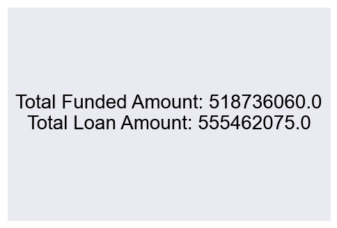

```python
Total_founded = df_clean[["funded_amount","loan_amount" ]].sum()
plt.figure(figsize=(6, 4))  # Adjust the figure size as needed

# Set a different background color
sns.set_style("darkgrid")  # Change to "whitegrid" or "white" for different backgrounds

# Plot the sum values as text with a different color
plt.text(0.5, 0.5,
         f"Total Funded Amount: {Total_founded['funded_amount']}\nTotal Loan Amount: {Total_founded['loan_amount']}",
         horizontalalignment='center', verticalalignment='center',
         fontsize=20, color='black')  # Change color to 'black' or other color

# Hide x-axis and y-axis ticks
plt.xticks([])
plt.yticks([])

plt.show()

Total_founded= df_clean["funded_amount"].sum()
Total_lohn= df_clean["loan_amount"].sum()
Prozentsatz_der_Investition = (Total_founded / Total_lohn)

fig = go.Figure(go.Indicator(
    value=Prozentsatz_der_Investition,
    title={'text': "Prozentsatz_der_Investition"},
    mode="gauge+number",
    gauge={
        'axis': {'range': [0.7, 1]},
        'bar': {'color': "darkblue"},
        'bgcolor': "white",
        'borderwidth': 2,
        'bordercolor': "gray",
        'steps': [
            {'range': [0.7, 0.8], 'color': 'red'},
            {'range': [0.8, 0.90], 'color': 'yellow'},
            {'range': [0.90, 1], 'color': 'green'}
        ],
        'threshold': {
            'line': {'color': "red", 'width': 4},
            'thickness': 0.75,
            'value': Prozentsatz_der_Investition
        }
    }
))

fig.show()
```

Unser Geschäftsmodell sieht gut aus: 93 % der Projekte sind finanziert.

### Step 10.1: Univariate Analyse

**Ziel 1:** Vergleichen den Gesamtbetrag der Investitionen in verschiedenen Ländern:

```python
country_fundedamount = df_clean.groupby('country')['funded_amount'].sum().sort_values(ascending=False)

df_country_fundedamount = pd.DataFrame({'Country': country_fundedamount.index, 'Total_Funded_Amount': country_fundedamount.values})

df_country_fundedamount
```

|  | Country | Total_Funded_Amount |
| --- | --- | --- |
| 0 | Philippines | 53138350.0 |
| 1 | Kenya | 31566840.0 |
| 2 | Peru | 30294700.0 |
| 3 | Paraguay | 29287375.0 |
| 4 | El Salvador | 23057125.0 |
| ... | ... | ... |
| 81 | Afghanistan | 14000.0 |
| 82 | Bhutan | 10000.0 |
| 83 | Vanuatu | 9250.0 |
| 84 | Guam | 395.0 |
| 85 | Virgin Islands | 0.0 |

86 rows × 2 columns

```python
# Erstellen Balkendiagramm
fig = px.bar(
    df_country_fundedamount,
    x='Country',
    y='Total_Funded_Amount',
    title='Gesamtbetrag nach Land',
    labels={'Country': 'Land', 'Total_Funded_Amount': 'Gesamtbetrag der Finanzierung'},
    color='Total_Funded_Amount',  # Add color to bars based on total funded amount
    color_continuous_scale='Inferno',  # Change color scale to yellow-green-blue
)

# Customize x-axis and y-axis appearance
fig.update_xaxes(title='Land', tickangle=45, tickfont=dict(size=10))  # Rotate labels and adjust font size
fig.update_yaxes(title='Gesamtbetrag nach Land', title_font=dict(size=14))  # Customize y-axis title

# Customize the title appearance
fig.update_layout(
    title_font=dict(size=24, family="Arial"),  # Change title font size and family
    title_x=0.5,  # Center the title
)

# Show the plot
fig.show()
```

Insgesamt bietet das Balkendiagramm eine visuelle Darstellung der Verteilung der insgesamt finanzierten Beträge auf die verschiedenen Länder und verdeutlicht die Unterschiede in den erhaltenen Mitteln zwischen den einzelnen Ländern. Die Länder, die die meisten Finanzierungen erhalten haben, sind die Philippinen, Kenia, Peru, Paraguay und El Salvador.  
Einige Länder erhalten hingegen vergleichsweise geringe Finanzierungen, wie beispielsweise die Virgin Islands, Guam und Vanuatu.

Um unsere Analyse zu vertiefen, planen wir, die Anzahl der Projekte pro Land genauer zu betrachten.

**Ziel 2:** Anzahl der Projekte pro Land:

```python
project_counts = df_clean['country'].value_counts().reset_index()
project_counts.columns = ['country', 'project_count']
project_counts
```

|  | country | project_count |
| --- | --- | --- |
| 0 | Philippines | 154248 |
| 1 | Kenya | 72996 |
| 2 | El Salvador | 39312 |
| 3 | Cambodia | 27042 |
| 4 | Pakistan | 26471 |
| ... | ... | ... |
| 81 | Afghanistan | 2 |
| 82 | Guam | 1 |
| 83 | Mauritania | 1 |
| 84 | Cote D'Ivoire | 1 |
| 85 | Bhutan | 1 |

86 rows × 2 columns

```python
# Erstellen Balkendiagramm Projektanzahl pro Land.
fig_project_counts = px.bar(
                project_counts,
                x='country',
                y='project_count',
                title='Anzahl von Projekten pro Land',
                labels={'country': 'Land', 'project_count': 'Anzahl von Projekten'},  # Custom labels
                color='project_count',  # Add color to bars based on project count
                color_continuous_scale='Inferno',  # Change color scale as desired
                )

fig_project_counts.update_xaxes(tickangle=45, tickfont=dict(size=10))  # Beschriftungen drehen und Schriftgröße anpassen
fig_project_counts.update_yaxes(title='Anzahl von Projekten', title_font=dict(size=14))  # Titel der y-Achse anpassen

# Anpassen des Erscheinungsbildes des Titels
fig_project_counts.update_layout(
    title_font=dict(size=20, family="Arial"),  # Schriftgröße und -familie des Titels ändern
    title_x=0.5,  # Zentrieren den Titel
)
fig_project_counts.show()
```

Länder mit mehr Finanzierung sind im Allgemeinen diejenigen mit mehr Projekten. Hier haben wir festgestellt, dass die Philippinen und Kenia, die den höchsten gefundenen Betrag haben, auch die meisten Projekte haben.

Wir möchten die folgen graph bewerben.  
Gesamtzahl der Projekte nach Ländern mit Geokoordinaten:

### Plot 1 zu bewerten:

```python
project_counts = df_clean.groupby('country').agg(
                                                project_count=('loan_amount', 'count'),
                                                total_funded_amount=('funded_amount', 'sum')
                                                ).reset_index()

# Erstellen eines Streudiagramms mit Geokoordinaten
fig = px.scatter_geo(
                    project_counts,
                    locations='country',
                    locationmode='country names',
                    color='project_count',
                    #hover_name='country',
                    size='total_funded_amount', # Verwende die 'total_funded_amount' für die Größe
                    size_max=20, # Maximalgröße für die Punktgröße
                    projection='natural earth',
                    title='Projekte insgesamt, aufgeschlüsselt nach Ländern und finanzierten Beträgen',
                    labels={'project_count': 'Anzahl der Projekten'}
                    )

# Hinzufügen der funded_amount als Text auf den Punkten
fig.update_traces(text=project_counts['total_funded_amount'], textposition='top center')

fig.show()
```

```python
project_counts.loc[project_counts["project_count"]>10000]
```

|  | country | project_count | total_funded_amount |
| --- | --- | --- | --- |
| 11 | Cambodia | 27042 | 17671250.0 |
| 15 | Colombia | 21192 | 11960775.0 |
| 20 | Ecuador | 13444 | 14542600.0 |
| 22 | El Salvador | 39312 | 23057125.0 |
| 29 | India | 10944 | 6309775.0 |
| 34 | Kenya | 72996 | 31566840.0 |
| 52 | Nicaragua | 11670 | 9791450.0 |
| 54 | Pakistan | 26471 | 12337825.0 |
| 57 | Paraguay | 11812 | 29287375.0 |
| 58 | Peru | 22169 | 30294700.0 |
| 59 | Philippines | 154248 | 53138350.0 |
| 71 | Tajikistan | 19496 | 13730325.0 |
| 77 | Uganda | 20313 | 14022125.0 |

Eines Streudiagramms mit Geokoordinaten gibt bessere Ausblick auf Verteilung von Projektenanzahl.

**Ziel 3:** Welches sind die 5 wichtigsten Sektoren in Bezug auf Investitionen?

```python
df_sector_total_founded = df_clean.groupby(by=["sector"], as_index=False).agg(investment=("funded_amount","sum")).sort_values(by="investment",ascending=False)
df_sector_total_founded
```

|  | sector | investment |
| --- | --- | --- |
| 0 | Agriculture | 131975995.0 |
| 6 | Food | 113884105.0 |
| 11 | Retail | 89880555.0 |
| 12 | Services | 42354675.0 |
| 2 | Clothing | 34484095.0 |
| 4 | Education | 29537295.0 |
| 8 | Housing | 20070425.0 |
| 10 | Personal Use | 12634325.0 |
| 1 | Arts | 11674755.0 |
| 13 | Transportation | 9749365.0 |
| 7 | Health | 9110725.0 |
| 3 | Construction | 6173450.0 |
| 9 | Manufacturing | 5297775.0 |
| 5 | Entertainment | 1000645.0 |
| 14 | Wholesale | 907875.0 |

```python
# Sortieren  DataFrame nach investment
df_sorted = df_sector_total_founded.sort_values(by="investment", ascending=False)

# Wählen Sie die TOP 5 Sektoren aus und berechnen Sie die Summe der übrigen Sektoren
top_5 = df_sorted.head(5)
other_sum = df_sorted.iloc[5:]["investment"].sum()

# Erstellen neuen DataFrame für das Kreisdiagramm
data_pie = pd.concat([top_5, pd.DataFrame({"sector": ["Others"], "investment": [other_sum]})])

# Manuelle Festlegung von Farben für jeden Sektor (einschließlich "Andere")
colors = ['#1f77b4',  '#ff7f0e', '#2ca02c', '#d62728', '#9467bd', 'grey']

# Erstellen Kreisdiagramm
fig = go.Figure(data=[
    go.Pie(
        labels=data_pie['sector'],
        values=data_pie['investment'],
        hovertemplate='%{label}<br>Investment: $%{value}<extra></extra>',
        textinfo='label+percent',
        hole=0.4,
        marker=dict(colors=colors)
    )
])

# Annotations erstellen
annotations = [
    dict(
        x=0.5,
        y=0.5,
        xref="paper",
        yref="paper",
        text="",
        showarrow=True,
        arrowhead=0,
        ax=0,
        ay=0
    )
]

# Annotations aktualisieren
fig.update_layout(annotations=annotations)

fig.update_layout(
    title="Top-5-Sektoren nach Investitionen",  # Titel einsetzen
    title_x=0.5,
    showlegend=False                            # Entfernen Sie die Legende
)

fig.show()
```

```python
result = result = df_clean.groupby(["country", "sector"]).agg(
            sector_count=("sector", "count"), volume=("funded_amount", "sum")).sort_values("sector_count", ascending=False).reset_index()
result
```

|  | country | sector | sector_count | volume |
| --- | --- | --- | --- | --- |
| 0 | Philippines | Retail | 52489 | 18569875.0 |
| 1 | Philippines | Food | 41848 | 14366300.0 |
| 2 | Philippines | Agriculture | 35144 | 11463600.0 |
| 3 | Kenya | Agriculture | 32702 | 16216120.0 |
| 4 | El Salvador | Agriculture | 13864 | 8211000.0 |
| ... | ... | ... | ... | ... |
| 974 | China | Construction | 1 | 1550.0 |
| 975 | Saint Vincent and the Grenadines | Entertainment | 1 | 3725.0 |
| 976 | China | Entertainment | 1 | 800.0 |
| 977 | Ukraine | Wholesale | 1 | 2550.0 |
| 978 | South Sudan | Manufacturing | 1 | 475.0 |

979 rows × 4 columns

```python
fig_sectors = px.scatter(
                        result,
                        x='country',
                        y='sector',
                        size="volume",
                        color="sector_count",
                        title='Projekte nach Sector'
                       )

# Passe die Achsentitel an
fig_sectors.update_xaxes(title_text='Land', tickangle=45)
fig_sectors.update_yaxes(title_text='Sektoren')

fig_sectors.show()
```

Agriculture, Food, Retail, Services und Closing Sektoren haben die meisten Investitionen.  
Der Manufacturing Sektor hat bei den im Rahmen von Kiva finanzierten Projekten keine große Bedeutung.

### Step 10.2: Bivariate Analyse

**Ziel 4:** Wir möchten Anzahl von Projekten und Investment pro Sektor analysieren.

```python
df_sector_total_founded = df_clean.groupby(by=["sector"], as_index=False).agg(investment=("funded_amount","sum"),number_projects=("sector", 'count')).sort_values(by="investment",ascending=False)
df_sector_total_founded
```

|  | sector | investment | number_projects |
| --- | --- | --- | --- |
| 0 | Agriculture | 131975995.0 | 173676 |
| 6 | Food | 113884105.0 | 134482 |
| 11 | Retail | 89880555.0 | 122527 |
| 12 | Services | 42354675.0 | 44420 |
| 2 | Clothing | 34484095.0 | 32307 |
| 4 | Education | 29537295.0 | 29974 |
| 8 | Housing | 20070425.0 | 30004 |
| 10 | Personal Use | 12634325.0 | 25422 |
| 1 | Arts | 11674755.0 | 11872 |
| 13 | Transportation | 9749365.0 | 15329 |
| 7 | Health | 9110725.0 | 9143 |
| 3 | Construction | 6173450.0 | 6189 |
| 9 | Manufacturing | 5297775.0 | 6154 |
| 5 | Entertainment | 1000645.0 | 820 |
| 14 | Wholesale | 907875.0 | 626 |

### Plot 2 zu bewerten:

```python
# Balkendiagramm mit benutzerdefiniertem Aussehen und Farbpalette erstellen
fig_sector_total_founded = px.bar(
    df_sector_total_founded,
    x="sector",
    y='investment',
    title='Gesamtinvestitionen pro Sektor',
    hover_name='sector',
    hover_data=['investment', 'number_projects'],
    color='number_projects',  # Hinzufügen von Farben zu Balken je nach Investition
    color_continuous_scale='Inferno',  # Farbskala auf reds ändern
)

fig_sector_total_founded.update_xaxes(tickangle=45, title='Sektor', tickfont=dict(size=10))  # Beschriftungen drehen und Schriftgröße anpassen
fig_sector_total_founded.update_yaxes(title='Investitionen', title_font=dict(size=14))  # Titel der y-Achse anpassen

fig_sector_total_founded.update_layout(
    title_font=dict(size=20, family="Arial"),  # Schriftgröße und -familie des Titels ändern
    title_x=0.5,  # Zentrieren den Titel
)

fig_sector_total_founded.show()
```

Agriculture, Food, Retail, Services und Closing Sektoren haben die meisten Investitionen und Anzahl von Projekten.

**Ziel 5:** Welches Geschlecht und wieviel Projekten nach Sektoren initiiert?

```python
grouped_for_sector_gender = df_clean.groupby("sector", as_index=False).agg({'male_count': 'sum', 'female_count': 'sum'}).sort_values(["female_count"], ascending=False)
grouped_for_sector_gender
```

|  | sector | male_count | female_count |
| --- | --- | --- | --- |
| 6 | Food | 39542 | 284664 |
| 0 | Agriculture | 110613 | 258280 |
| 11 | Retail | 26747 | 199056 |
| 2 | Clothing | 8176 | 80106 |
| 12 | Services | 13102 | 62576 |
| 10 | Personal Use | 25703 | 47824 |
| 8 | Housing | 9346 | 27385 |
| 4 | Education | 12151 | 21902 |
| 1 | Arts | 2117 | 21431 |
| 7 | Health | 4053 | 10932 |
| 13 | Transportation | 7790 | 9698 |
| 9 | Manufacturing | 2846 | 6584 |
| 3 | Construction | 4293 | 6158 |
| 14 | Wholesale | 335 | 597 |
| 5 | Entertainment | 456 | 550 |

```python
fig_for_country_gender = px.bar(grouped_for_sector_gender, x='sector', y=['male_count', 'female_count'],
              barmode='group', title='Anzahl von Borrowers gender per Sector',
              color_discrete_sequence=["#5133ff", "#ff33a2"])
fig_for_country_gender.update_xaxes(title_text='Sector')
fig_for_country_gender.update_yaxes(title_text='Anzahl von Gender')
fig_for_country_gender.update_layout(legend_title_text='Gender')
fig_for_country_gender.show()
```

Frauen sind bei der Anzahl der Projekte in KIVA stärker vertreten als Männer und auch in Food, Agriculture und Retail Sektoren sehr aktiv.

**Ziel 6:** Investment vs Loan Vergleich pro Sektor:

```python
df_founded_vs_loan = df_clean.groupby(by="sector",as_index=False).agg(sum_of_investment=("funded_amount","sum"),sum_of_loan=("loan_amount","sum")).sort_values(by='sum_of_investment', ascending=False)
df_founded_vs_loan
```

|  | sector | sum_of_investment | sum_of_loan |
| --- | --- | --- | --- |
| 0 | Agriculture | 131975995.0 | 140994325.0 |
| 6 | Food | 113884105.0 | 120203825.0 |
| 11 | Retail | 89880555.0 | 96996325.0 |
| 12 | Services | 42354675.0 | 47224775.0 |
| 2 | Clothing | 34484095.0 | 36930725.0 |
| 4 | Education | 29537295.0 | 30440325.0 |
| 8 | Housing | 20070425.0 | 22327050.0 |
| 10 | Personal Use | 12634325.0 | 13377475.0 |
| 1 | Arts | 11674755.0 | 12063925.0 |
| 13 | Transportation | 9749365.0 | 10907900.0 |
| 7 | Health | 9110725.0 | 9779075.0 |
| 3 | Construction | 6173450.0 | 6530800.0 |
| 9 | Manufacturing | 5297775.0 | 5384725.0 |
| 5 | Entertainment | 1000645.0 | 1366650.0 |
| 14 | Wholesale | 907875.0 | 934175.0 |

```python
fig_sectors = px.bar(df_founded_vs_loan, x='sector', y=['sum_of_investment', 'sum_of_loan'],
              barmode='group', title='Investment vs Loan Vergleich pro Sektor')
fig_sectors.update_xaxes(tickangle=45,title_text='Sektor')
fig_sectors.update_yaxes(title_text='Investment')
fig_sectors.update_layout(legend_title_text='Legend')
fig_sectors.show()
```

Die meisten Paare sind fast gleich, aber wir sehen ein klein Unterschied in Agriculture, Food und Retail Sektoren.

**Ziel 7:** Wir möchten analysieren welche Laufzeit für die Kreditrückzahlung sind mehr attraktive:

```python
# Gruppiere und aggregiere die Daten
df_tmp1 = df_clean.groupby(by=["sector","term_in_months"], as_index=False).agg(
                        term_in_months_count=("term_in_months", "count"),
                        sum_of_investment=("funded_amount", "sum")
                        ).sort_values(by="sum_of_investment", ascending=False)

fig_sectors = px.scatter(
                        df_tmp1,
                        x='sector',
                        y='sum_of_investment',
                        color="term_in_months",
                        size="term_in_months_count",
                        title='Summe der Investitionen pro Sektor nach Anzahl von Monaten',
                        color_continuous_scale=px.colors.sequential.Plasma, # Verwende das Farbschema "Plasma"
                        opacity=0.8, # Erhöhe die Opazität für intensivere Farben
                        range_color=[0, 20] # Begrenze die Farbskala bis 20 Monate
                        )

# Passe die Achsentitel an
fig_sectors.update_xaxes(title_text='Sektor')
fig_sectors.update_yaxes(title_text='Gesamtbetrag der Investitionen')

fig_sectors.show()
```

Die attraktive Laufzeit für die Kreditrückzahlung beträgt 14 Monate in Agriculture Sector. Für Food und Retail Sektoren ist die Laufzeit von Kreditrückzahlung 8 Monaten.

### Step 10.3: Multivariate Analyse

**Ziel 8:** Wir möchten untersuchen, die Summe der Investitionen pro Sektor nach Rückzahlungsintervall.

```python
df_tmp = df_clean.groupby(by=["sector","repayment_interval"], as_index=False).agg(repayment_interval_count=("repayment_interval","count"), sum_of_investment=("funded_amount", "sum")).sort_values(by="sector",ascending=True)
df_tmp.head(3)
```

|  | sector | repayment_interval | repayment_interval_count | sum_of_investment |
| --- | --- | --- | --- | --- |
| 0 | Agriculture | bullet | 40695 | 32947470.0 |
| 1 | Agriculture | irregular | 45592 | 25836000.0 |
| 2 | Agriculture | monthly | 87350 | 73184650.0 |

```python
fig_sectors = px.scatter(df_tmp, x='sector', y='sum_of_investment', color="repayment_interval",
              size="repayment_interval_count",
              title='Summe der Investitionen pro Sektor nach Rückzahlungsintervall')
fig_sectors.update_xaxes(title_text='Sector')
fig_sectors.update_yaxes(title_text='Gesamtbetrag der Investitionen')
fig_sectors.update_layout(legend_title_text='Rückzahlungsintervall')
fig_sectors.show()
```

Wir stellen fest, dass das monatliche Rückzahlungsintervall einen höheren Gesamtbetrag an Investitionen pro Sektor aufweist.

**Ziel 9:** Analyse des Rückzahlungsintervalls.

```python
df_donut = df_clean.groupby("repayment_interval", as_index=False).agg(sum=("funded_amount","sum")).sort_values("sum",ascending=False)
df_donut
```

|  | repayment_interval | sum |
| --- | --- | --- |
| 2 | monthly | 298612175.0 |
| 1 | irregular | 170560400.0 |
| 0 | bullet | 49423510.0 |
| 3 | weekly | 139975.0 |

```python
colors = ['#1f77b4',  '#ff7f0e', '#2ca02c', '#d62728']

# Erstellen Kreisdiagramm
fig = go.Figure(data=[
    go.Pie(
        labels=df_donut['repayment_interval'],
        values=df_donut['sum'],
        hovertemplate='%{label}<br>Investment: $%{value}<extra></extra>',
        textinfo='label+percent',
        hole=0.4,
        marker=dict(colors=colors)
    )
])

# Annotations erstellen
annotations = [
    dict(
        x=0.5,
        y=0.5,
        xref="paper",
        yref="paper",
        text="",
        showarrow=True,
        arrowhead=0,
        ax=0,
        ay=0
    )
]

# Annotations aktualisieren
fig.update_layout(annotations=annotations)

fig.update_layout(
    title="Investitionen pro Repayment Interval",  # Titel einsetzen
    title_x=0.5,
    showlegend=True                            # Entfernen Sie die Legende
)

fig.show()
```

**Ziel 10:** Summe der Investitionen pro Sektor nach Rückzahlungsintervall:

```python
df_clean[(df_clean['sector'] == 'Transportation') & (df_clean['activity'] == 'Motorcycle Transport')].groupby(['repayment_interval']).agg({'funded_amount': 'sum'})
```

| repayment_interval | funded_amount |
| --- | --- |
| bullet | 46200.0 |
| irregular | 1085050.0 |
| monthly | 1558525.0 |

```python
# Dash
app = dash.Dash(__name__)

app.layout = html.Div([
    dcc.Dropdown(
        id='sector-dropdown',
        options=[{'label': sector, 'value': sector} for sector in df_clean['sector'].unique()],
        value=df_clean['sector'].unique()[0]
    ),
    dcc.Dropdown(
        id='activity-dropdown',
    ),
    dcc.Graph(id='repayment-graph'),
])

@app.callback(
    Output('activity-dropdown', 'options'),
    Input('sector-dropdown', 'value')
)
def update_activity_dropdown(selected_sector):
    filtered_data = df_clean[df_clean['sector'] == selected_sector]
    activity_options = [{'label': activity, 'value': activity} for activity in filtered_data['activity'].unique()]
    return activity_options

@app.callback(
    Output('repayment-graph', 'figure'),
    [Input('sector-dropdown', 'value'), Input('activity-dropdown', 'value')]
)
def update_repayment_graph(selected_sector, selected_activity):
    filtered_data = df_clean[(df_clean['sector'] == selected_sector) & (df_clean['activity'] == selected_activity)]
    repayment_amounts = filtered_data.groupby('repayment_interval')['funded_amount'].sum().reset_index()

    fig = px.bar(repayment_amounts, x='repayment_interval', y='funded_amount', title='Distribution of Funded Amounts by Repayment Intervals')
    return fig

if __name__ == '__main__':
    app.run_server(debug=True, port=8209)
# app.run(jupyter_mode="tab", port=8098)
```

[interactive chart not shown]

Wie aus dem Kreisdiagramm hervorgeht, ist die "monatliche" Rückzahlung die häufigste Form der Rückzahlung von Investitionen. Im Dash können wir sehen, wie sich diese Zahl je nach Sektor und "activity" unterscheidet.

**Ziel 11:** Erstellen ein Dashboard für die Verteilung des Investitionen pro Sektor und pro borower category in Form eines Kreisdiagramms.  
Berechnung der Projektanzahl auf der Grundlage von drei Gruppen von Kreditnehmern ("nur weiblich", "nur männlich", "gemischtes Geschlecht") und Land:

```python
project_counts_per_gender = df_clean.groupby(['sector', 'borrower_category'])['sector'].count().reset_index(name='project_count_per_gender')

# Calculate total project count per country
total_project_count = df_clean.groupby(['sector'])['sector'].count().reset_index(name='total_project_count')

# Merge the two DataFrames based on 'country'
totalproject_gender = pd.merge(project_counts_per_gender, total_project_count, on='sector', how='left')

# Sort the DataFrame in descending order based on project_count_per_gender
totalproject_gender = totalproject_gender.sort_values(by='project_count_per_gender', ascending=False)

totalproject_gender
```

|  | sector | borrower_category | project_count_per_gender | total_project_count |
| --- | --- | --- | --- | --- |
| 19 | Food | Only Female | 112158 | 134482 |
| 1 | Agriculture | Only Female | 111562 | 173676 |
| 34 | Retail | Only Female | 103989 | 122527 |
| 2 | Agriculture | Only Male | 47473 | 173676 |
| 37 | Services | Only Female | 33218 | 44420 |
| 7 | Clothing | Only Female | 27625 | 32307 |
| 25 | Housing | Only Female | 21335 | 30004 |
| 13 | Education | Only Female | 18340 | 29974 |
| 20 | Food | Only Male | 14678 | 134482 |
| 0 | Agriculture | Mixed Gender | 14641 | 173676 |
| 35 | Retail | Only Male | 14495 | 122527 |
| 31 | Personal Use | Only Female | 11620 | 25422 |
| 14 | Education | Only Male | 11426 | 29974 |
| 4 | Arts | Only Female | 10227 | 11872 |
| 38 | Services | Only Male | 10124 | 44420 |
| 26 | Housing | Only Male | 8324 | 30004 |
| 40 | Transportation | Only Female | 8172 | 15329 |
| 18 | Food | Mixed Gender | 7646 | 134482 |
| 30 | Personal Use | Mixed Gender | 7007 | 25422 |
| 41 | Transportation | Only Male | 6909 | 15329 |
| 32 | Personal Use | Only Male | 6795 | 25422 |
| 22 | Health | Only Female | 5708 | 9143 |
| 33 | Retail | Mixed Gender | 4043 | 122527 |
| 28 | Manufacturing | Only Female | 3608 | 6154 |
| 11 | Construction | Only Male | 3147 | 6189 |
| 23 | Health | Only Male | 2969 | 9143 |
| 10 | Construction | Only Female | 2764 | 6189 |
| 8 | Clothing | Only Male | 2728 | 32307 |
| 29 | Manufacturing | Only Male | 2359 | 6154 |
| 6 | Clothing | Mixed Gender | 1954 | 32307 |
| 5 | Arts | Only Male | 1236 | 11872 |
| 36 | Services | Mixed Gender | 1078 | 44420 |
| 21 | Health | Mixed Gender | 466 | 9143 |
| 3 | Arts | Mixed Gender | 409 | 11872 |
| 16 | Entertainment | Only Female | 402 | 820 |
| 17 | Entertainment | Only Male | 396 | 820 |
| 24 | Housing | Mixed Gender | 345 | 30004 |
| 43 | Wholesale | Only Female | 344 | 626 |
| 9 | Construction | Mixed Gender | 278 | 6189 |
| 44 | Wholesale | Only Male | 268 | 626 |
| 39 | Transportation | Mixed Gender | 248 | 15329 |
| 12 | Education | Mixed Gender | 208 | 29974 |
| 27 | Manufacturing | Mixed Gender | 187 | 6154 |
| 15 | Entertainment | Mixed Gender | 22 | 820 |
| 42 | Wholesale | Mixed Gender | 14 | 626 |

```python
# Pivot the result DataFrame for a better presentation
pivot_result = totalproject_gender.pivot(index='sector',columns='borrower_category', values='project_count_per_gender')

# Fill NaN values with 0
pivot_result = pivot_result.fillna(0).astype(int)
# Add a column for total project count
pivot_result['Total Projects'] = pivot_result.sum(axis=1)

# Sort the pivot_result DataFrame in descending order of Total Projects
pivot_result = pivot_result.sort_values(by='Total Projects', ascending=False)
pivot_result.columns.name = None
a1 = pivot_result.reset_index()
a1
```

|  | sector | Mixed Gender | Only Female | Only Male | Total Projects |
| --- | --- | --- | --- | --- | --- |
| 0 | Agriculture | 14641 | 111562 | 47473 | 173676 |
| 1 | Food | 7646 | 112158 | 14678 | 134482 |
| 2 | Retail | 4043 | 103989 | 14495 | 122527 |
| 3 | Services | 1078 | 33218 | 10124 | 44420 |
| 4 | Clothing | 1954 | 27625 | 2728 | 32307 |
| 5 | Housing | 345 | 21335 | 8324 | 30004 |
| 6 | Education | 208 | 18340 | 11426 | 29974 |
| 7 | Personal Use | 7007 | 11620 | 6795 | 25422 |
| 8 | Transportation | 248 | 8172 | 6909 | 15329 |
| 9 | Arts | 409 | 10227 | 1236 | 11872 |
| 10 | Health | 466 | 5708 | 2969 | 9143 |
| 11 | Construction | 278 | 2764 | 3147 | 6189 |
| 12 | Manufacturing | 187 | 3608 | 2359 | 6154 |
| 13 | Entertainment | 22 | 402 | 396 | 820 |
| 14 | Wholesale | 14 | 344 | 268 | 626 |

```python
category_sector_funding = df_clean.groupby(['borrower_category', 'sector'])['funded_amount'].sum().reset_index()

borrower_category_sector_funding = category_sector_funding.pivot(index='borrower_category', columns='sector', values='funded_amount')
borrower_category_sector_funding.columns.name = None
borrower_category_sector_funding
```

| borrower_category | Agriculture | Arts | Clothing | Construction | Education | Entertainment | Food | Health | Housing | Manufacturing | Personal Use | Retail | Services | Transportation | Wholesale |
| --- | --- | --- | --- | --- | --- | --- | --- | --- | --- | --- | --- | --- | --- | --- | --- |
| Mixed Gender | 18760250.0 | 1400300.0 | 6862100.0 | 995225.0 | 545525.0 | 56600.0 | 23269400.0 | 961350.0 | 486175.0 | 546000.0 | 2893000.0 | 12663150.0 | 3001825.0 | 621875.0 | 34850.0 |
| Only Female | 76924035.0 | 8679790.0 | 25201100.0 | 2134950.0 | 17706205.0 | 440995.0 | 78036025.0 | 5498125.0 | 13604090.0 | 2368325.0 | 5691725.0 | 66464365.0 | 28729790.0 | 4210950.0 | 369675.0 |
| Only Male | 36291710.0 | 1594665.0 | 2420895.0 | 3043275.0 | 11285565.0 | 503050.0 | 12578680.0 | 2651250.0 | 5980160.0 | 2383450.0 | 4049600.0 | 10753040.0 | 10623060.0 | 4916540.0 | 503350.0 |

### Plot 3 zu bewerten:

```python
sector_gender_app = JupyterDash(__name__)

# Define the app layout
sector_gender_app.layout = html.Div(children=[
    html.H1(children="Sector Gender App", style={"text-align": "center"}),
    dcc.Dropdown(id="dd_sector",
                 options=[{'label': sector, 'value': sector} for sector in df_clean['sector'].unique()],
                 placeholder="Please select a sector",
                 style={"width": "60%"}),
    dcc.Graph(id="graph", figure={})
])

# Define the callback function
@sector_gender_app.callback(
    Output(component_id="graph", component_property="figure"),
    Input(component_id="dd_sector", component_property="value")
)
def update_graph(selected_sector):
    if selected_sector is None:
        return {}

    category_sector_funding = df_clean[df_clean['sector'] == selected_sector].groupby(['borrower_category'])['funded_amount'].sum().reset_index()
    fig = px.pie(category_sector_funding, values='funded_amount',
                 names='borrower_category',
                 title=f'Höhe der Investitionen nach {selected_sector} Sektor und Geschlecht')

    return fig


# sector_gender_app.run(jupyter_mode="tab", port=8098)
if __name__ == '__main__':
    sector_gender_app.run_server(debug=True, port=8312)
```

[interactive chart not shown]

```
Dash app running on http://127.0.0.1:8312/
```

## Step 10.4: Storytelling

Kiva ist in 86 Ländern tätig. Es ist erreicht $518,736,060 von Investment und $555,462,075 von Loans. Das bedeutet 93% Projekts sind finanziert.  
In dieser Untersuchung befassen wir uns mit einem Datensatz, der Einblicke in die Verteilung der Finanzmittel auf verschiedene Sektoren und Länder gewährt. Wir begeben uns auf eine Reise, um Muster, Trends und potenzielle Möglichkeiten für positive Veränderungen aufzudecken.

Das zentrale Thema unserer Geschichte dreht sich um die starke Kraft der Finanzierung. Sie dient als dynamischer Katalysator, der bemerkenswerte Transformationen vorantreibt. Auf dieser fesselnden Reise lernen wir die transformative Kraft der Finanzierung zu schätzen, die Länder, Sektoren und Menschen in einem gemeinsamen Streben nach Fortschritt und Verbesserung vereint.

**Insights nach Land** Die Länder, die die meisten Finanzierungen erhalten haben, sind die Philippinen, Kenia, Peru, Paraguay und El Salvador. Einige Länder erhalten hingegen vergleichsweise geringe Finanzierungen, wie beispielsweise die Virgin Islands, Guam und Vanuatu. Länder mit mehr Finanzierung sind im Allgemeinen diejenigen mit mehr Projekten. Hier haben wir festgestellt, dass die Philippinen und Kenia, die den höchsten gefundenen Betrag haben, auch die meisten Projekte haben. Als neue Idee sollten wir unsere Plattform und ihre Vorteile in bestimmten Ländern bekannt machen.

**Insights nach Gender** Bei der Untersuchung der Daten haben wir wertvolle Einblicke in die unterschiedlichen geschlechtsspezifischen Prioritäten in den verschiedenen Sektoren gewonnen. So zeigen die Daten beispielsweise, dass in Sektoren wie Landwirtschaft, Kunst, Kleidung, Bildung, Ernährung, Gesundheit, Wohnen, Einzelhandel für den persönlichen Gebrauch und Dienstleistungen der Schwerpunkt auf der Stärkung der Rolle der Frau liegt. In den Sektoren verarbeitendes Gewerbe, Transport, Großhandel, Baugewerbe und Unterhaltung sind die Männer in der Überzahl. In den Sektoren Lebensmittel, Einzelhandel und Bekleidung beobachten wir ein konzertiertes Bemühen, sowohl Männer als auch Frauen zu unterstützen und so die wirtschaftliche Selbstbestimmung und ein nachhaltiges Wachstum zu fördern. Dieser Ansatz spiegelt einen strategischen Ansatz zur Förderung der Gleichstellung der Geschlechter bei gleichzeitiger Förderung der wirtschaftlichen Entwicklung wider.

In dieser Analyse haben Frauen einen größeren Beitrag in mehreren Sektoren (Agriculture,Arts,Clothing,Education,Food ,Health,Housing, Personal Use Retail,Services) als Männer, außer in den Sektoren ( Manufacturing,Transportation, Wholesale, Construction, Entertainment) ,und gemischte Geschlechter haben einen geringeren Beitrag geleistet.

**Insights "repayment_interval"** Hier können wir sehen, dass die monatliche Rückzahlung des Kredits mit 58 % am beliebtesten ist. Gleichzeitig ist die unregelmäßige Rückzahlung mit 32 % am zweitbeliebtesten. Dies muss genauer betrachtet werden, vielleicht unter diesem Namen auch alle anderen Arten/Intervalle von Rückzahlung betrachtet.

*Da es sich bei crisp-dm um einen iterativen Prozess handelt, können die Indikatoren in nachfolgenden Analysen auch nach Kategorien analysiert werden, z. B. Kategorisierung nach "funded_amount", "term in month", "activity" und cetera.*